# Statistical Learning

Authors

Class by Professor Federico Castelletti

Notes by Maria Briones

# Multiple Regression

## Linear regression

We implement linear regression on the Advertising dataset

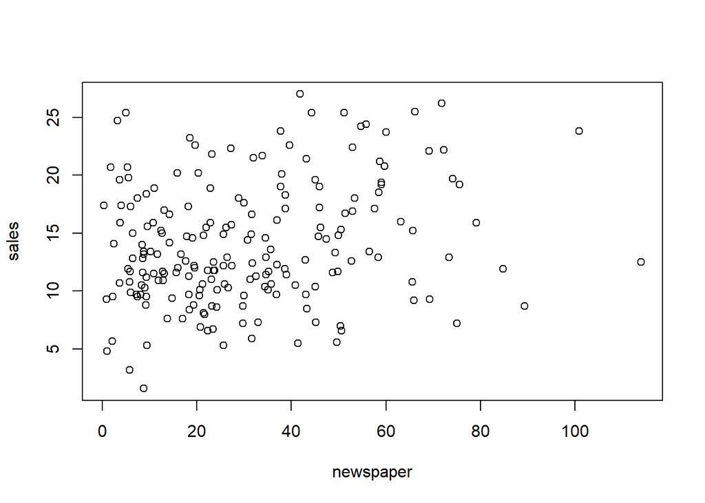

```r
advert = read.csv(paste0(datawd,"/advertising.csv"), row.names = 1)
attach(advert)

plot(newspaper, sales)
```

We can use function ‘lm()’ (linear model) to build a linear model. We consider sales (Y) as a function TV (X1), radio (X2) and newspaper (X3).

$$Y = \beta_0 + \beta_1 X_1 + ... + \beta_p X_p + \epsilon$$

```r
out_lm = lm(sales ~ TV + radio + newspaper)

summary(out_lm)
```

```
Call:
lm(formula = sales ~ TV + radio + newspaper)

Residuals:
    Min      1Q  Median      3Q     Max
-8.8277 -0.8908  0.2418  1.1893  2.8292

Coefficients:
             Estimate Std. Error t value Pr(>|t|)
(Intercept)  2.938889   0.311908   9.422   <2e-16 ***
TV           0.045765   0.001395  32.809   <2e-16 ***
radio        0.188530   0.008611  21.893   <2e-16 ***
newspaper   -0.001037   0.005871  -0.177     0.86
---
Signif. codes:  0 '***' 0.001 '**' 0.01 '*' 0.05 '.' 0.1 ' ' 1

Residual standard error: 1.686 on 196 degrees of freedom
Multiple R-squared:  0.8972,    Adjusted R-squared:  0.8956
F-statistic: 570.3 on 3 and 196 DF,  p-value: < 2.2e-16
```

We can se that $\beta_3 = \beta_newspaper$ is not significant ($p-value=0.86>0.1$), which means that newspaper does not have a significant effect on sales (the null hypothesis of the test on this model is that $\beta_3 = 0$).

### Model fit

We can extract results from this output such as the coefficients and residuals, or in case we wish to evaluate the model fit we can retrieve the adjusted R-squared value.

```r
summary_lm = summary(out_lm)
summary_lm$adj.r.squared
```

```
[1] 0.8956373
```

```r
# output of OUT_lm is a list, we can retrieve particular values followin list logic
summary(out_lm)[["coefficients"]]["newspaper", "Pr(>|t|)"] #pvalue of newspaper
```

```
[1] 0.8599151
```

On this case the adjusted R-squared value is 0.8956, which means that the model explains 89.56% of the variance in sales (dependent variable). Another measure to compute the goodness of fit is the Mean Squared Error (MSE) for this we need to estimate de fitted values and compute the squared difference between observations and fitted values.

```r
## fitted values for sales
y_hat = predict(out_lm)

## real values for sales
y = sales
n = length(sales)

## MSE
mse = sum((y - y_hat)^2)/n
mse
```

```
[1] 2.784126
```

### Predictions

The function `predict()` can be used to make prediction if we add the argument *newdata*. The new dataframe must contain values from the covariates for which we want to make predictions.

```r
# Predict sales for new values of predictors for instance TV = 250, radio = 50, newspaper = 0
predict(out_lm, newdata = data.frame(TV = 250, radio = 50, newspaper = 0)) # is the predicted value of sales
```

```
       1
23.80655
```

## Logistic regression

A logistic model is adequate when our response variable is binary. This means we can define Y’s distribution as Bernoulli with parameter $p$ (the probability of success). The model is defined as:

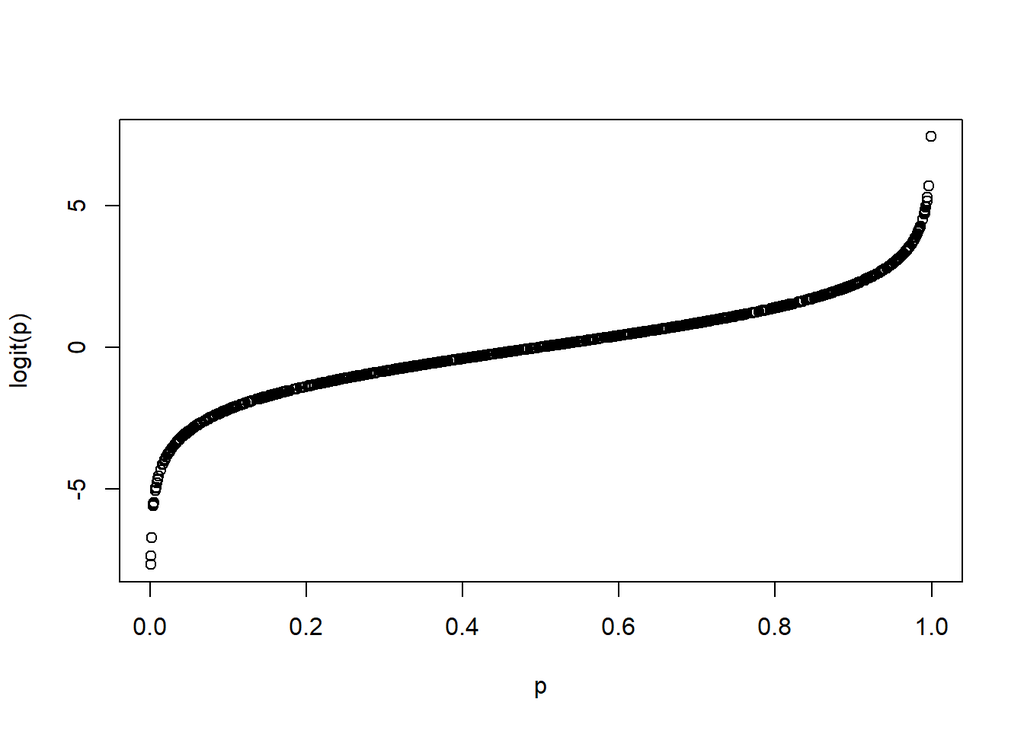

```r
p <- runif(1000, 0, 1)

logit = log(p/(1-p))
plot(p, logit, type = "p", xlab = "p", ylab = "logit(p)")
```

We’ll fit the logistic model on the Titanic dataset, to explore the main factors that impacted the probability of survival of passengers. We erase all the observation with NA’s (complete case analysis) mainly on ‘Age’, to avoid problems with model fitting.

```r
titanic = read.csv(paste0(datawd,"/titanic_train.csv"), row.names = 1)
attach(titanic)

titanic |> skim()
```

Data summary

| Name | titanic |
| --- | --- |
| Number of rows | 891 |
| Number of columns | 11 |
| _______________________ |  |
| Column type frequency: |  |
| character | 5 |
| numeric | 6 |
| ________________________ |  |
| Group variables | None |

**Variable type: character**

| skim_variable | n_missing | complete_rate | min | max | empty | n_unique | whitespace |
| --- | --- | --- | --- | --- | --- | --- | --- |
| Name | 0 | 1 | 12 | 82 | 0 | 891 | 0 |
| Sex | 0 | 1 | 4 | 6 | 0 | 2 | 0 |
| Ticket | 0 | 1 | 3 | 18 | 0 | 681 | 0 |
| Cabin | 0 | 1 | 0 | 15 | 687 | 148 | 0 |
| Embarked | 0 | 1 | 0 | 1 | 2 | 4 | 0 |

**Variable type: numeric**

| skim_variable | n_missing | complete_rate | mean | sd | p0 | p25 | p50 | p75 | p100 | hist |
| --- | --- | --- | --- | --- | --- | --- | --- | --- | --- | --- |
| Survived | 0 | 1.0 | 0.38 | 0.49 | 0.00 | 0.00 | 0.00 | 1 | 1.00 | ▇▁▁▁▅ |
| Pclass | 0 | 1.0 | 2.31 | 0.84 | 1.00 | 2.00 | 3.00 | 3 | 3.00 | ▃▁▃▁▇ |
| Age | 177 | 0.8 | 29.70 | 14.53 | 0.42 | 20.12 | 28.00 | 38 | 80.00 | ▂▇▅▂▁ |
| SibSp | 0 | 1.0 | 0.52 | 1.10 | 0.00 | 0.00 | 0.00 | 1 | 8.00 | ▇▁▁▁▁ |
| Parch | 0 | 1.0 | 0.38 | 0.81 | 0.00 | 0.00 | 0.00 | 0 | 6.00 | ▇▁▁▁▁ |
| Fare | 0 | 1.0 | 32.20 | 49.69 | 0.00 | 7.91 | 14.45 | 31 | 512.33 | ▇▁▁▁▁ |

```r
#head(titanic)

# to avoid NA
titanic = titanic[complete.cases(titanic),]
```

We select the variables of interest.

```r
# Select the response variable y (Survived, 0 no, 1 yes)
y = titanic$Survived

# Select covariates
X.tmp = as.data.frame(titanic[,c(2,4,5:7,9)])
str(X.tmp)
```

```
'data.frame':   714 obs. of  6 variables:
 $ Pclass: int  3 1 3 1 3 1 3 3 2 3 ...
 $ Sex   : chr  "male" "female" "female" "female" ...
 $ Age   : num  22 38 26 35 35 54 2 27 14 4 ...
 $ SibSp : int  1 1 0 1 0 0 3 0 1 1 ...
 $ Parch : int  0 0 0 0 0 0 1 2 0 1 ...
 $ Fare  : num  7.25 71.28 7.92 53.1 8.05 ...
```

We then convert factor variables like `Sex`(female, male) into dummies using the function `model.matrix()`. By default model.matrix includes a unit column (for the intercept term) so we remove it.

```r
X = model.matrix(y ~ ., X.tmp)[,-1]
#head(X)
```

With this inputs we fit our model with the function `glm` under family “binomial” and link “logit”.

```r
out_glm = glm(y ~ X, family = binomial(link = logit))
summary(out_glm)
```

```
Call:
glm(formula = y ~ X, family = binomial(link = logit))

Coefficients:
             Estimate Std. Error z value Pr(>|z|)
(Intercept)  5.389003   0.603734   8.926  < 2e-16 ***
XPclass     -1.242249   0.163191  -7.612 2.69e-14 ***
XSexmale    -2.634845   0.219609 -11.998  < 2e-16 ***
XAge        -0.043953   0.008179  -5.374 7.70e-08 ***
XSibSp      -0.375755   0.127361  -2.950  0.00317 **
XParch      -0.061937   0.122925  -0.504  0.61436
XFare        0.002160   0.002493   0.866  0.38627
---
Signif. codes:  0 '***' 0.001 '**' 0.01 '*' 0.05 '.' 0.1 ' ' 1

(Dispersion parameter for binomial family taken to be 1)

    Null deviance: 964.52  on 713  degrees of freedom
Residual deviance: 635.81  on 707  degrees of freedom
AIC: 649.81

Number of Fisher Scoring iterations: 5
```

Other variables had a less miningfull impact on the probability of survival, though we can se that Age had a significant negative effect, this meant children were more prompt to survive than adults.

We can provide graphical representations of the results:

```r
## Build the data matrix (including now a unit column for the intercept term)
XX = cbind(1, X)
head(XX)
```

```
    Pclass Sexmale Age SibSp Parch    Fare
1 1      3       1  22     1     0  7.2500
2 1      1       0  38     1     0 71.2833
3 1      3       0  26     0     0  7.9250
4 1      1       0  35     1     0 53.1000
5 1      3       1  35     0     0  8.0500
7 1      1       1  54     0     0 51.8625
```

```r
## Select the estimated regression coefficients from the glm output
beta_hat = out_glm$coefficients
beta_hat
```

```
 (Intercept)      XPclass     XSexmale         XAge       XSibSp       XParch
 5.389003106 -1.242248625 -2.634844835 -0.043952596 -0.375754871 -0.061937366
       XFare
 0.002160034
```

```r
## Estimate probabilities by computing the linear predictor (XX%*%beta_hat) and applying the inverse logit function
pi_hat = exp(XX%*%beta_hat)/(1 + exp(XX%*%beta_hat))
pi_hat |> head()
```

```
        [,1]
1 0.09115283
2 0.90506165
3 0.63102300
4 0.91272388
5 0.07631228
7 0.32092900
```

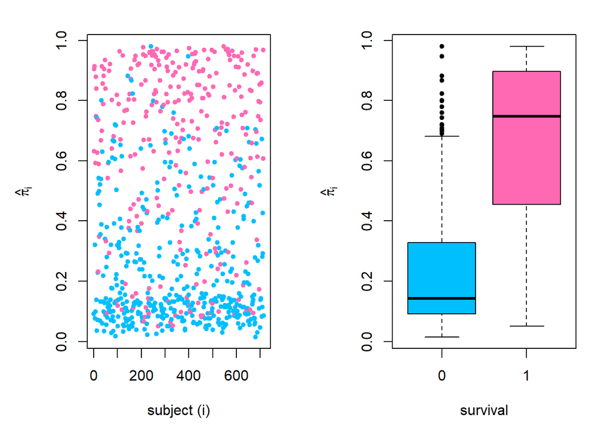

```r
## colors for graph ( based on vector of survivers and non-survivors)
col_lab = c()
col_lab[y == 0] = "deepskyblue1"
col_lab[y == 1] = "hotpink"

#plot
par(mfrow = c(1,2), mar = c(5,5,2,2))
plot(pi_hat, col = col_lab, pch = 20, xlab = "subject (i)", ylab = expression(hat(pi)[i]))
boxplot(pi_hat ~ y, xlab = "survival", ylab = expression(hat(pi)[i]), col = c("deepskyblue1", "hotpink"), pch = 20)
```

### Model fit

On a logistic model we use a confussion matrix and derived measures to evaluate the model fit. We can set a threshold of 0.5 to classify passengers as survivors or non-survivors and then compare the true and estimated values of y to compute the error rate (ER) and other measures such as precision, type I and II errors.

```r
## For classification purposes, we can set y_fat = 1 if pi_hat > 0.5, otherwise y_hat = 0
y_hat = ifelse(pi_hat > 0.5, 1, 0)

## Compare true and estimated values of y and compute the Error Rate (ER) (confusion matrix, also error type I and II)
confusion = table(y, y_hat)
confusion
```

```
   y_hat
y     0   1
  0 364  60
  1  80 210
```

```r
er = sum(y != y_hat)/length(y)
er
```

```
[1] 0.1960784
```

### Prediction

```r
## Consider two passengers with the following levels of the covariates
x.star.rose = c(1, 1, 0, 17, 0, 2, 150)
x.star.jack = c(1, 3, 1, 19, 0, 0, 40)

## Estimate the corresponding probabilities of survival
pi_hat_rose = exp(x.star.rose%*%beta_hat)/(1 + exp(x.star.rose%*%beta_hat))
pi_hat_jack = exp(x.star.jack%*%beta_hat)/(1 + exp(x.star.jack%*%beta_hat))

c(pi_hat_rose, pi_hat_jack)
```

```
[1] 0.9733950 0.1517056
```

# Cross validation

We will use the Auto dataset (with 392 observations) to illustrate the concept of cross validation. We want to predict the miles per gallon (mpg) of a car based on its horsepower. As our dependent variable is quantitative we will use the already seen linear model.

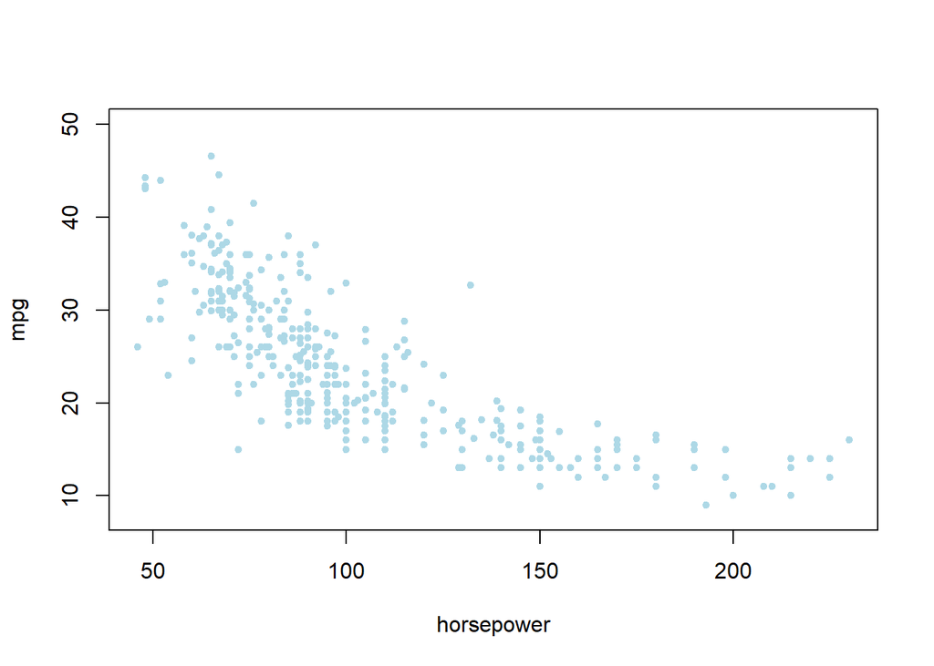

```r
#plot auto vs horsepower
plot(Auto$horsepower, Auto$mpg, ylab = "mpg", xlab = "horsepower", col = "lightblue", pch = 20, ylim = c(8,50))
```

```r
n = nrow(Auto)
```

## Validation set approach

Our main goal in this section is to evaluate our model fit and compare it with polynomial forms of the same predictor.

### Data split

First, we must make the partition based on a % of the data this will allow to get a train and test subset. On this case 50% for train and 50% for test.

```r
# 1. construct a training set by randomly selecting n/2 observations
train = sample(1:n, n/2)
train |> head() # these observations will be used to fit the model
```

```
[1]  13   8 258 123 262  87
```

```r
# The remaining observations will be used as a test (validation) set
test = setdiff(1:n, train) # difference between sets 1:n and train
test |> head()
```

```
[1]  1  3  4  6  7 11
```

### Training the model

Then we fit our linear model on the training set.

```r
#2. fit the model on the training set
lm_fit = lm(mpg ~ horsepower, data = Auto, subset = train) #subset is used to fit linear model using train only

summary(lm_fit)
```

```
Call:
lm(formula = mpg ~ horsepower, data = Auto, subset = train)

Residuals:
     Min       1Q   Median       3Q      Max
-13.0321  -3.5504  -0.6868   2.8536  17.5196

Coefficients:
             Estimate Std. Error t value Pr(>|t|)
(Intercept) 38.814252   1.016903   38.17   <2e-16 ***
horsepower  -0.149752   0.009084  -16.48   <2e-16 ***
---
Signif. codes:  0 '***' 0.001 '**' 0.01 '*' 0.05 '.' 0.1 ' ' 1

Residual standard error: 4.953 on 194 degrees of freedom
Multiple R-squared:  0.5835,    Adjusted R-squared:  0.5813
F-statistic: 271.8 on 1 and 194 DF,  p-value: < 2.2e-16
```

What we are doing with the model is estimate a line that best fits the relationship between mpg and horsepower on the training set. We can add this line to the scatter plot of mpg vs horsepower to visually check the fit of the model.

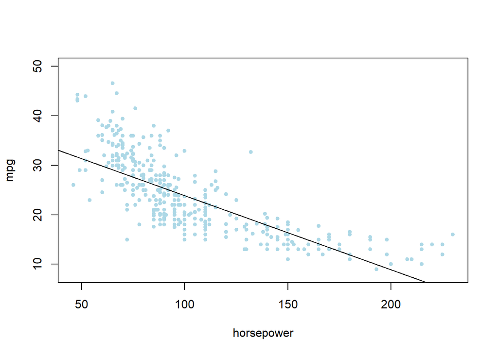

```r
plot(Auto$horsepower, Auto$mpg, ylab = "mpg", xlab = "horsepower", col = "lightblue", pch = 20, ylim = c(8,50))
abline(lm_fit) # add my regression model in the scatter plot
```

This is usefull only if we keep in mind that the fitted line is based on the training set, while the base scatter plot shows the entire dataset.

### Fitness of the model

Now we apply the trained model on the test subset to compute the goodness of fit measure, on this case, the *MSE*.

```r
# Create the test dataset
Auto_test = Auto[test,]

# fitted values for mpg on test set (yhat)
Auto_test = Auto_test |>
  mutate(fitted_mpg = predict(lm_fit, newdata = Auto_test))

head(Auto_test)
```

```
   mpg cylinders displacement horsepower weight acceleration year origin
1   18         8          307        130   3504           12   70      1
3   18         8          318        150   3436           11   70      1
4   16         8          304        150   3433           12   70      1
6   15         8          429        198   4341           10   70      1
7   14         8          454        220   4354            9   70      1
11  15         8          383        170   3563           10   70      1
                        name fitted_mpg
1  chevrolet chevelle malibu  19.346525
3         plymouth satellite  16.351490
4              amc rebel sst  16.351490
6           ford galaxie 500   9.163407
7           chevrolet impala   5.868869
11       dodge challenger se  13.356456
```

```r
# Compute the test MSE
mean((Auto_test$mpg - Auto_test$fitted_mpg)^2)
```

```
[1] 23.95133
```

### Model comparison

We use the function `poly()` to create the polynomial terms of the covariate horsepower.

Keep in mind that poly provides orthogonal polynomials, this can be checked as the values from poly output are zero-centered. This is not done by standarization but through **Gram-Schmidt orthogonalization**, this not only zero-centers the variables but also makes them orthogonal to avoid multicollinearity problems, so each term captures a genuinely independent piece of the variance.

Orthogonal polynomials are harder to interpret directly. The practical workflow is: use `poly()` for cross validation and model selection, then to communicate results, refit the chosen degree with the raw variables.

```r
# with poly(horsepower,2) we include both horsepower and horsepower^2
poly(Auto$horsepower, 2) |> head()
```

```
              1            2
[1,] 0.03354377 -0.052723127
[2,] 0.07952903 -0.009329288
[3,] 0.05982106 -0.036299630
[4,] 0.05982106 -0.036299630
[5,] 0.04668241 -0.047302373
[6,] 0.12288656  0.094214809
```

```r
poly(Auto$horsepower, 2, raw = T) |> head() # with raw = T they are not centered
```

```
       1     2
[1,] 130 16900
[2,] 165 27225
[3,] 150 22500
[4,] 150 22500
[5,] 140 19600
[6,] 198 39204
```

```r
## Using polynomial regression of order 2
lm_fit_2 = lm(mpg ~ poly(horsepower,2), data = Auto, subset = train)

# centering variables do not affect model fitting only the value of the intercept
fitted_test_2 = predict(lm_fit_2, newdata = Auto_test)  # fitted values for mpg (only for obs' within the test set)
fitted_test_2 |> head()
```

```
       1        3        4        6        7       11
16.84621 14.51282 14.51282 13.02036 14.27436 13.18621
```

```r
# Compute the test MSE
mean((Auto_test$mpg - fitted_test_2)^2)
```

```
[1] 18.85783
```

```r
## [3] Using polynomial regression of order 3
lm_fit_3 = lm(mpg ~ poly(horsepower,3), data = Auto, subset = train)

fitted_test_3 = predict(lm_fit_3, newdata = Auto_test)

mean((Auto_test$mpg - fitted_test_3)^2)
```

```
[1] 20.1094
```

Now or model can be sensitive to the particular random split of the data.

## Leave-One-Out Cross-Validation

LOO-CV — reveals if any single observation is driving results. beeing a Cross validation method, LOOCV can be used to evaluate the form of the model (as we used 50-50 cross validation to compare linear, square and cubic models) but LOO-CV is more informative about data sensitivity.

Without leaving the linear model context, we will change to the `gml` function since LOO-cross validation is easier to implement on this package. First, we fit the linear model.

```r
fit_lm = glm(mpg ~ horsepower, data = Auto)
fit_lm2 = glm(mpg ~ poly(horsepower,2), data = Auto)
```

Then apply `cv.glm`, this function calculates the estimated K-fold cross-validation prediction error for generalized linear models. If K is not specified then LOO-CV is used by default.

```r
loocv_out = cv.glm(Auto, fit_lm)
loocv_out$delta[1] # this is the estimated average test error for LOOCV (CV_n)
```

```
[1] 24.23151
```

```r
loocv_out2 = cv.glm(Auto, fit_lm2)
loocv_out2$delta[1]
```

```
[1] 19.24821
```

As we can see our conclussion about the linear model being worse than the polynomial model of order 2 is confirmed by LOOCV, since the estimated test error for the linear model is higher than the one for the polynomial model of order 2.

Unfortunately, LOOCV can be computationally expensive when the dataset is large, since it requires fitting the model n times (where n is the number of observations). In this case, we can apply cross-validation to each polynomial model to choose the best one. We do this in the following *k-fold cross validation*.

## k-fold cross validation

We apply k-fold cross validation to discriminate between polynomial models of order from 1 to 8. We fix k = 10 (10 folds) and then divide the n = 392 observations into 10 groups of approximately same size.

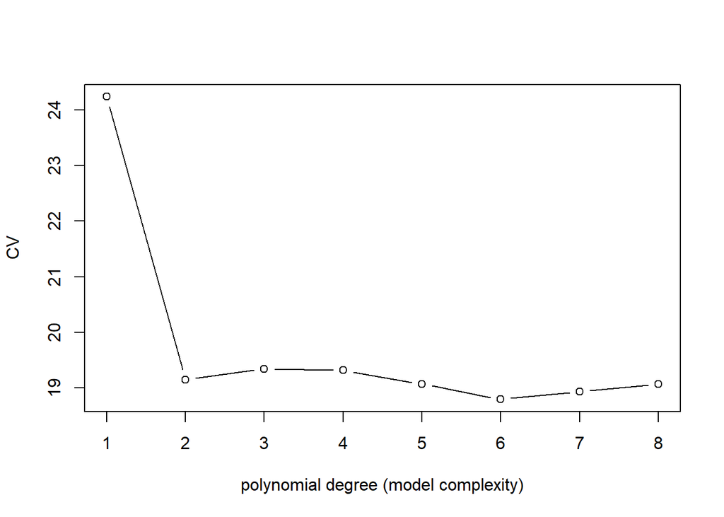

```r
# Create empty vector to store the 8 CVs (one for each polynomial model)
cv.error.8 = rep(NA, 8)

#loop to computhe the CV for each polynomial model of order from 1 to 8
for(i in 1:8){
  lm_fit = glm(mpg ~ poly(horsepower,i), data = Auto)
  cv.error.8[i] = cv.glm(Auto, lm_fit, K = 10)$delta[1]
}

# we plot to anaylise
plot(cv.error.8, xlab = "polynomial degree (model complexity)", ylab = "CV", type = "b")
```

The plot confirms the choice of the polynomial model of order 2, there are more complicated polynomial models with lower CV but the improvement is not significant and model complexity increases variance and risk of overfitting.

# Linear Model selection

To study the model selection we consider the credit dataset (with 400 observations). We take as dependent variable the balance and nine predictors.

```r
y = Credit$Balance # Response variable is Balance (Y)
X = Credit[,2:10] #p = 9 predictors

X |> skim()
```

Data summary

| Name | X |
| --- | --- |
| Number of rows | 400 |
| Number of columns | 9 |
| _______________________ |  |
| Column type frequency: |  |
| factor | 3 |
| numeric | 6 |
| ________________________ |  |
| Group variables | None |

**Variable type: factor**

| skim_variable | n_missing | complete_rate | ordered | n_unique | top_counts |
| --- | --- | --- | --- | --- | --- |
| Gender | 0 | 1 | FALSE | 2 | Fem: 207, Ma: 193 |
| Student | 0 | 1 | FALSE | 2 | No: 360, Yes: 40 |
| Married | 0 | 1 | FALSE | 2 | Yes: 245, No: 155 |

**Variable type: numeric**

| skim_variable | n_missing | complete_rate | mean | sd | p0 | p25 | p50 | p75 | p100 | hist |
| --- | --- | --- | --- | --- | --- | --- | --- | --- | --- | --- |
| Income | 0 | 1 | 45.22 | 35.24 | 10.35 | 21.01 | 33.12 | 57.47 | 186.63 | ▇▂▁▁▁ |
| Limit | 0 | 1 | 4735.60 | 2308.20 | 855.00 | 3088.00 | 4622.50 | 5872.75 | 13913.00 | ▆▇▃▁▁ |
| Rating | 0 | 1 | 354.94 | 154.72 | 93.00 | 247.25 | 344.00 | 437.25 | 982.00 | ▆▇▃▁▁ |
| Cards | 0 | 1 | 2.96 | 1.37 | 1.00 | 2.00 | 3.00 | 4.00 | 9.00 | ▇▇▂▁▁ |
| Age | 0 | 1 | 55.67 | 17.25 | 23.00 | 41.75 | 56.00 | 70.00 | 98.00 | ▆▇▇▇▁ |
| Education | 0 | 1 | 13.45 | 3.13 | 5.00 | 11.00 | 14.00 | 16.00 | 20.00 | ▂▅▇▇▂ |

Note that not all this variables are numeric so we need to transform them in order to apply linear regression.

## Best subset selection

We want to fit all the linear models including a subset of the predictors. There are `choose(p,q)` different models including exactly k predictors. For excample if we have p = 9 predictors, there are `choose(9,2) = 36` different models including exactly 2 predictors that I must consider and compare. We can find the structure of models as:

```r
p = ncol(X) # total number of predictors

# models including exactly 2 predictors from the total of 9
choose(p, 2)
```

```
[1] 36
```

```r
# possible structures of 2-factor models
combn(1:p, 2) |> head() # each column corresponds to a model, i.e. to the labels of the predictors included in the model
```

```
     [,1] [,2] [,3] [,4] [,5] [,6] [,7] [,8] [,9] [,10] [,11] [,12] [,13] [,14]
[1,]    1    1    1    1    1    1    1    1    2     2     2     2     2     2
[2,]    2    3    4    5    6    7    8    9    3     4     5     6     7     8
     [,15] [,16] [,17] [,18] [,19] [,20] [,21] [,22] [,23] [,24] [,25] [,26]
[1,]     2     3     3     3     3     3     3     4     4     4     4     4
[2,]     9     4     5     6     7     8     9     5     6     7     8     9
     [,27] [,28] [,29] [,30] [,31] [,32] [,33] [,34] [,35] [,36]
[1,]     5     5     5     5     6     6     6     7     7     8
[2,]     6     7     8     9     7     8     9     8     9     9
```

```r
#in case of 3 factors models
choose(p, 3) # 84 models including exactly 3 predictors
```

```
[1] 84
```

```r
combn(1:p, 3)  |> head()
```

```
     [,1] [,2] [,3] [,4] [,5] [,6] [,7] [,8] [,9] [,10] [,11] [,12] [,13] [,14]
[1,]    1    1    1    1    1    1    1    1    1     1     1     1     1     1
[2,]    2    2    2    2    2    2    2    3    3     3     3     3     3     4
[3,]    3    4    5    6    7    8    9    4    5     6     7     8     9     5
     [,15] [,16] [,17] [,18] [,19] [,20] [,21] [,22] [,23] [,24] [,25] [,26]
[1,]     1     1     1     1     1     1     1     1     1     1     1     1
[2,]     4     4     4     4     5     5     5     5     6     6     6     7
[3,]     6     7     8     9     6     7     8     9     7     8     9     8
     [,27] [,28] [,29] [,30] [,31] [,32] [,33] [,34] [,35] [,36] [,37] [,38]
[1,]     1     1     2     2     2     2     2     2     2     2     2     2
[2,]     7     8     3     3     3     3     3     3     4     4     4     4
[3,]     9     9     4     5     6     7     8     9     5     6     7     8
     [,39] [,40] [,41] [,42] [,43] [,44] [,45] [,46] [,47] [,48] [,49] [,50]
[1,]     2     2     2     2     2     2     2     2     2     2     2     3
[2,]     4     5     5     5     5     6     6     6     7     7     8     4
[3,]     9     6     7     8     9     7     8     9     8     9     9     5
     [,51] [,52] [,53] [,54] [,55] [,56] [,57] [,58] [,59] [,60] [,61] [,62]
[1,]     3     3     3     3     3     3     3     3     3     3     3     3
[2,]     4     4     4     4     5     5     5     5     6     6     6     7
[3,]     6     7     8     9     6     7     8     9     7     8     9     8
     [,63] [,64] [,65] [,66] [,67] [,68] [,69] [,70] [,71] [,72] [,73] [,74]
[1,]     3     3     4     4     4     4     4     4     4     4     4     4
[2,]     7     8     5     5     5     5     6     6     6     7     7     8
[3,]     9     9     6     7     8     9     7     8     9     8     9     9
     [,75] [,76] [,77] [,78] [,79] [,80] [,81] [,82] [,83] [,84]
[1,]     5     5     5     5     5     5     6     6     6     7
[2,]     6     6     6     7     7     8     7     7     8     8
[3,]     7     8     9     8     9     9     8     9     9     9
```

We could build a loop cycle iterating over j = 1,…,p and the collection of models with exactly q predictors. Fortunately, function ‘regsubsets’ already implements best subset selection.

```r
out_subset  = regsubsets(y ~ ., data = X, nvmax = p) # 'nvmax' fix the maximum number of predictors (q) that can be included

#str(out_subset) # is a list

# Display for each number of predictors included (q = 1,...,p) the best model
reg_summary = summary(out_subset)
reg_summary
```

```
Subset selection object
Call: regsubsets.formula(y ~ ., data = X, nvmax = p)
9 Variables  (and intercept)
             Forced in Forced out
Income           FALSE      FALSE
Limit            FALSE      FALSE
Rating           FALSE      FALSE
Cards            FALSE      FALSE
Age              FALSE      FALSE
Education        FALSE      FALSE
GenderFemale     FALSE      FALSE
StudentYes       FALSE      FALSE
MarriedYes       FALSE      FALSE
1 subsets of each size up to 9
Selection Algorithm: exhaustive
         Income Limit Rating Cards Age Education GenderFemale StudentYes
1  ( 1 ) " "    " "   "*"    " "   " " " "       " "          " "
2  ( 1 ) "*"    " "   "*"    " "   " " " "       " "          " "
3  ( 1 ) "*"    " "   "*"    " "   " " " "       " "          "*"
4  ( 1 ) "*"    "*"   " "    "*"   " " " "       " "          "*"
5  ( 1 ) "*"    "*"   "*"    "*"   " " " "       " "          "*"
6  ( 1 ) "*"    "*"   "*"    "*"   "*" " "       " "          "*"
7  ( 1 ) "*"    "*"   "*"    "*"   "*" " "       "*"          "*"
8  ( 1 ) "*"    "*"   "*"    "*"   "*" "*"       "*"          "*"
9  ( 1 ) "*"    "*"   "*"    "*"   "*" "*"       "*"          "*"
         MarriedYes
1  ( 1 ) " "
2  ( 1 ) " "
3  ( 1 ) " "
4  ( 1 ) " "
5  ( 1 ) " "
6  ( 1 ) " "
7  ( 1 ) " "
8  ( 1 ) " "
9  ( 1 ) "*"
```

The shown output involves one column for each predictor and one row for each model (for each number of predictors included). The star indicates the best predictors for each model. For example, the best model with 1 predictor is the one using the variable ‘Rating’.

Of course this decision is based on a criterion, we can use adjusted R squared, RSS, Cp, BIC, etc but all this criterion are equivalent for a same factor level. The function `regsubsets()` computes all these measures for each model and we can use them to choose the best model among the p options.

```r
reg_summary$adjr2 # These are the 9 R squared, one for each of the 9 best models
```

```
[1] 0.7452098 0.8744888 0.9494991 0.9531099 0.9535789 0.9539961 0.9540098
[8] 0.9539575 0.9538946
```

```r
reg_summary$rss #Sum of Squared Errors (SSE)
```

```
[1] 21435122 10532541  4227219  3915058  3866091  3821620  3810759  3805359
[9]  3800814
```

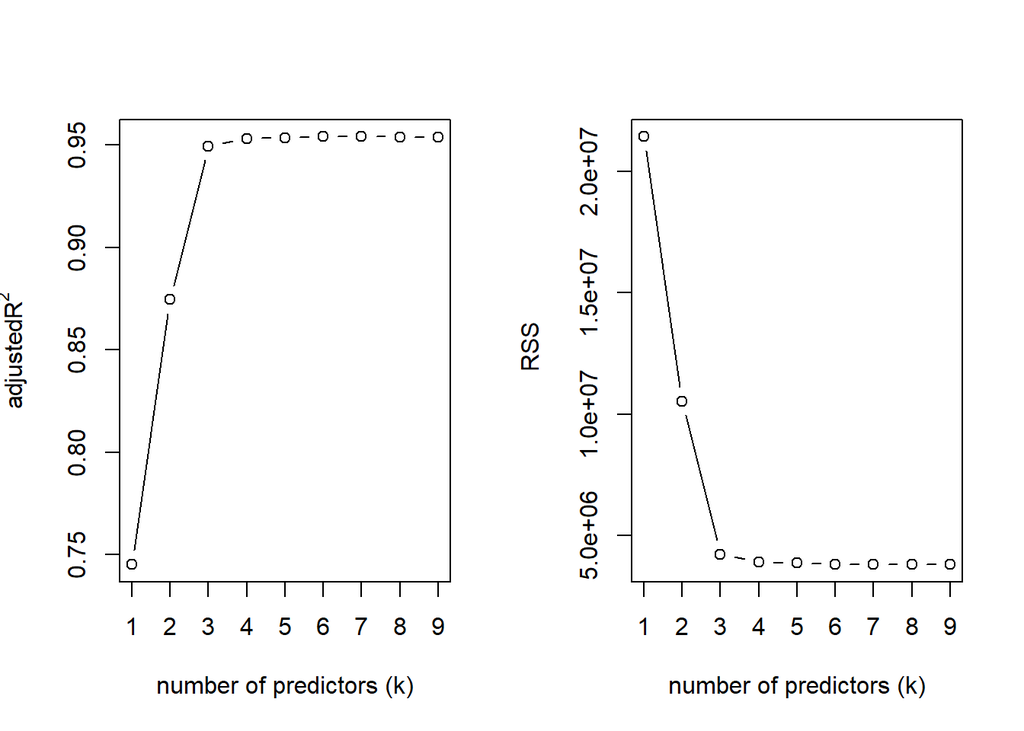

```r
par(mfrow = c(1,2))
plot(reg_summary$adjr2, xlab = "number of predictors (k)", ylab = expression(adjustedR^2), type = "b", xaxt = "none")
axis(1, 0:p)
plot(reg_summary$rss, xlab = "number of predictors (k)", ylab = " RSS", type = "b", xaxt = "none")
axis(1, 0:p)
```

This suggest we should select the model with 3 predictors which are ‘Income’, ‘Rating’ and ‘StudentYes’.

Unfortunately, Best subset selection model rapidly becomes computationally infeasible when the number of predictors is large. Exhaustive search becomes impractical around p > 30–40 variables, which is when you’d switch to forward/backward. In this cases, we change to setpwise selection methods.

## Setpwise selection methods

For this we modify the function `regsubsets()` and change the search algorithm (not the objective function) via the `method` argument which we can set to exhaustive, forward, backward or seqrep.

- exhaustive: guaranteed global optimum at each k, but high cost (best subset selection)
- forward: greedy, can miss better subsets (gets trapped in local optima)
- backward: ame problem, different direction
- seqrep: better than forward/backward but still not guaranteed optimal

The `method="forward"` option sets our algorithm to start from a model without factors. On the first step the algorithm chooses the variable which maximizes R squared and is significant at the 10%. On the second step the model just searches for the second best variable in addition to the variable selected on the first step. This process is repeated until reaching step number p.

```r
out_fwd = regsubsets(y ~ ., X, nvmax = p, method = "forward")
reg_summary_fwd = summary(out_fwd)
reg_summary_fwd
```

```
Subset selection object
Call: regsubsets.formula(y ~ ., X, nvmax = p, method = "forward")
9 Variables  (and intercept)
             Forced in Forced out
Income           FALSE      FALSE
Limit            FALSE      FALSE
Rating           FALSE      FALSE
Cards            FALSE      FALSE
Age              FALSE      FALSE
Education        FALSE      FALSE
GenderFemale     FALSE      FALSE
StudentYes       FALSE      FALSE
MarriedYes       FALSE      FALSE
1 subsets of each size up to 9
Selection Algorithm: forward
         Income Limit Rating Cards Age Education GenderFemale StudentYes
1  ( 1 ) " "    " "   "*"    " "   " " " "       " "          " "
2  ( 1 ) "*"    " "   "*"    " "   " " " "       " "          " "
3  ( 1 ) "*"    " "   "*"    " "   " " " "       " "          "*"
4  ( 1 ) "*"    "*"   "*"    " "   " " " "       " "          "*"
5  ( 1 ) "*"    "*"   "*"    "*"   " " " "       " "          "*"
6  ( 1 ) "*"    "*"   "*"    "*"   "*" " "       " "          "*"
7  ( 1 ) "*"    "*"   "*"    "*"   "*" " "       "*"          "*"
8  ( 1 ) "*"    "*"   "*"    "*"   "*" "*"       "*"          "*"
9  ( 1 ) "*"    "*"   "*"    "*"   "*" "*"       "*"          "*"
         MarriedYes
1  ( 1 ) " "
2  ( 1 ) " "
3  ( 1 ) " "
4  ( 1 ) " "
5  ( 1 ) " "
6  ( 1 ) " "
7  ( 1 ) " "
8  ( 1 ) " "
9  ( 1 ) "*"
```

```r
reg_summary_fwd$adjr2
```

```
[1] 0.7452098 0.8744888 0.9494991 0.9517033 0.9535789 0.9539961 0.9540098
[8] 0.9539575 0.9538946
```

The forward-step selection supports the idea of picking the 3 factor’s model (with ‘Income’, ‘Rating’ and ‘StudentYes’) since the adjusted R squared from this model captures more variance than the precedent models, more complex models marginally capture more variance and thus risk overfitting.

On the other hand, `method="backward"` starts from the p factor model and removes the less significant one (with a threshold of 10%).

```r
out_bwd = regsubsets(y ~ ., X, nvmax = p, method = "backward")
reg_summary_bwd = summary(out_bwd)
reg_summary_bwd
```

```
Subset selection object
Call: regsubsets.formula(y ~ ., X, nvmax = p, method = "backward")
9 Variables  (and intercept)
             Forced in Forced out
Income           FALSE      FALSE
Limit            FALSE      FALSE
Rating           FALSE      FALSE
Cards            FALSE      FALSE
Age              FALSE      FALSE
Education        FALSE      FALSE
GenderFemale     FALSE      FALSE
StudentYes       FALSE      FALSE
MarriedYes       FALSE      FALSE
1 subsets of each size up to 9
Selection Algorithm: backward
         Income Limit Rating Cards Age Education GenderFemale StudentYes
1  ( 1 ) " "    "*"   " "    " "   " " " "       " "          " "
2  ( 1 ) "*"    "*"   " "    " "   " " " "       " "          " "
3  ( 1 ) "*"    "*"   " "    " "   " " " "       " "          "*"
4  ( 1 ) "*"    "*"   " "    "*"   " " " "       " "          "*"
5  ( 1 ) "*"    "*"   "*"    "*"   " " " "       " "          "*"
6  ( 1 ) "*"    "*"   "*"    "*"   "*" " "       " "          "*"
7  ( 1 ) "*"    "*"   "*"    "*"   "*" " "       "*"          "*"
8  ( 1 ) "*"    "*"   "*"    "*"   "*" "*"       "*"          "*"
9  ( 1 ) "*"    "*"   "*"    "*"   "*" "*"       "*"          "*"
         MarriedYes
1  ( 1 ) " "
2  ( 1 ) " "
3  ( 1 ) " "
4  ( 1 ) " "
5  ( 1 ) " "
6  ( 1 ) " "
7  ( 1 ) " "
8  ( 1 ) " "
9  ( 1 ) "*"
```

```r
reg_summary_bwd$adjr2
```

```
[1] 0.7418753 0.8704576 0.9484265 0.9531099 0.9535789 0.9539961 0.9540098
[8] 0.9539575 0.9538946
```

One more time we see that the model suppores the 3 factor’s model since it shows a good balance between captured variance and risk of overfitting. Yet on this case, the selected fator are ‘Income’, ‘Limit’ and ‘StudentYes’, discarding previously choosen ‘Rating’.

In general, forward and backward selection do not guarantee to find the best model, but they are computationally more efficient than best subset selection.

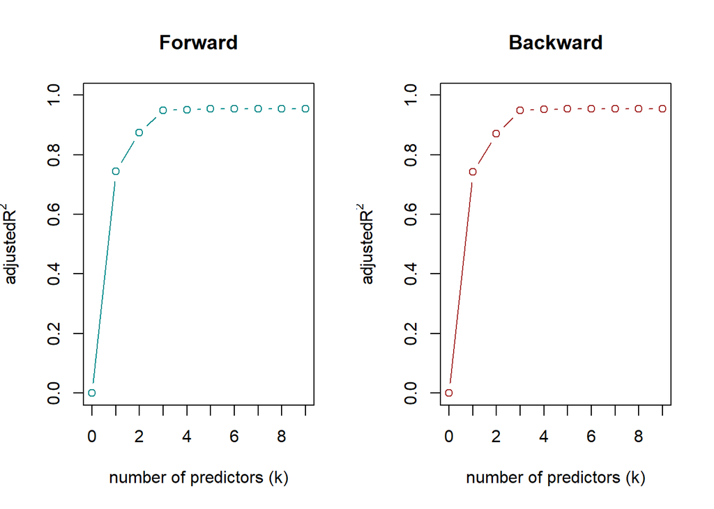

```r
par(mfrow = c(1,2))

plot(0:p, c(0, reg_summary_fwd$adjr2), ylim = c(0,1), xlab = "number of predictors (k)", type = "b",
     ylab = expression(adjustedR^2), xaxt = "none", col = "cyan4", main = "Forward")
axis(1, 0:p)

plot(0:p, c(0, reg_summary_bwd$adjr2), ylim = c(0,1), xlab = "number of predictors (k)", type = "b",
     ylab = expression(adjustedR^2), xaxt = "none", col = "brown", main = "Backward")
axis(1, 0:p)
```

### Logit procedure

Let’s apply the same procedure on a context of classification. We can’t predict the presence of Breast cancer. Information about the data set can be read on the [archive](https://archive.ics.uci.edu/ml/datasets/Breast+Cancer+Coimbra).

```r
breast = read.csv(paste0(datawd,"/breast.csv"), header = TRUE)
breast |> skim()
```

Data summary

| Name | breast |
| --- | --- |
| Number of rows | 116 |
| Number of columns | 10 |
| _______________________ |  |
| Column type frequency: |  |
| numeric | 10 |
| ________________________ |  |
| Group variables | None |

**Variable type: numeric**

| skim_variable | n_missing | complete_rate | mean | sd | p0 | p25 | p50 | p75 | p100 | hist |
| --- | --- | --- | --- | --- | --- | --- | --- | --- | --- | --- |
| Age | 0 | 1 | 57.30 | 16.11 | 24.00 | 45.00 | 56.00 | 71.00 | 89.00 | ▃▇▅▇▃ |
| BMI | 0 | 1 | 27.58 | 5.02 | 18.37 | 22.97 | 27.66 | 31.24 | 38.58 | ▅▆▇▅▃ |
| Glucose | 0 | 1 | 97.79 | 22.53 | 60.00 | 85.75 | 92.00 | 102.00 | 201.00 | ▅▇▁▁▁ |
| Insulin | 0 | 1 | 10.01 | 10.07 | 2.43 | 4.36 | 5.92 | 11.19 | 58.46 | ▇▁▁▁▁ |
| HOMA | 0 | 1 | 2.69 | 3.64 | 0.47 | 0.92 | 1.38 | 2.86 | 25.05 | ▇▁▁▁▁ |
| Leptin | 0 | 1 | 26.62 | 19.18 | 4.31 | 12.31 | 20.27 | 37.38 | 90.28 | ▇▃▂▁▁ |
| Adiponectin | 0 | 1 | 10.18 | 6.84 | 1.66 | 5.47 | 8.35 | 11.82 | 38.04 | ▇▅▂▁▁ |
| Resistin | 0 | 1 | 14.73 | 12.39 | 3.21 | 6.88 | 10.83 | 17.76 | 82.10 | ▇▂▁▁▁ |
| MCP.1 | 0 | 1 | 534.65 | 345.91 | 45.84 | 269.98 | 471.32 | 700.08 | 1698.44 | ▇▇▃▁▁ |
| Classification | 0 | 1 | 1.55 | 0.50 | 1.00 | 1.00 | 2.00 | 2.00 | 2.00 | ▆▁▁▁▇ |

Our response variable is Classification which takes the value 1 for healthy control and 2 for cancer patients. For model conveniencie we re-encode the variable to be 0-1. We use the remaining 9 numeric variables as predictors. Because or variable is binary we need to change into a logistic model.

```r
# recode dependent variable
y = ifelse(breast$Classification == 1, 0, 1) #For convenience I convert it into a 0-1 variable

# Select the predictors
X = breast[,-10]
```

Best subset, Forward and Backward selection for generalized linear models (including logistic regression), are not implemented in the `library leaps`. We can find this functions on the `library bestgml`.

```r
out_subset = bestglm(Xy = cbind(X,y), #data
                     family = binomial(link = "logit"), #logit model
                     IC = "AIC" #informaton criterion to find the best fit
                     )

summary(out_subset) #is our best model significantly better than the null model?
```

```
Fitting algorithm:  AIC-glm
Best Model:
            df deviance
Null Model 111 115.5405
Full Model 115 159.5665

    likelihood-ratio test - GLM

data:  H0: Null Model vs. H1: Best Fit AIC-glm
X = 44.026, df = 4, p-value = 6.337e-09
```

```r
summary(out_subset$BestModel) # description of our best model.
```

```
Call:
glm(formula = y ~ ., family = family, data = Xi, weights = weights)

Coefficients:
            Estimate Std. Error z value Pr(>|z|)
(Intercept) -4.58114    2.06646  -2.217 0.026630 *
BMI         -0.15207    0.04941  -3.078 0.002085 **
Glucose      0.07921    0.02108   3.758 0.000171 ***
Insulin      0.06790    0.03889   1.746 0.080837 .
Resistin     0.06963    0.03030   2.298 0.021548 *
---
Signif. codes:  0 '***' 0.001 '**' 0.01 '*' 0.05 '.' 0.1 ' ' 1

(Dispersion parameter for binomial family taken to be 1)

    Null deviance: 159.57  on 115  degrees of freedom
Residual deviance: 115.54  on 111  degrees of freedom
AIC: 125.54

Number of Fisher Scoring iterations: 6
```

```r
# to retrieve the q best models with their AICs
out_subset$Subsets
```

```
   Intercept   Age   BMI Glucose Insulin  HOMA Leptin Adiponectin Resistin
0       TRUE FALSE FALSE   FALSE   FALSE FALSE  FALSE       FALSE    FALSE
1       TRUE FALSE FALSE    TRUE   FALSE FALSE  FALSE       FALSE    FALSE
2       TRUE FALSE  TRUE    TRUE   FALSE FALSE  FALSE       FALSE    FALSE
3       TRUE FALSE  TRUE    TRUE   FALSE FALSE  FALSE       FALSE     TRUE
4*      TRUE FALSE  TRUE    TRUE    TRUE FALSE  FALSE       FALSE     TRUE
5       TRUE  TRUE  TRUE    TRUE    TRUE FALSE  FALSE       FALSE     TRUE
6       TRUE  TRUE  TRUE    TRUE    TRUE FALSE  FALSE       FALSE     TRUE
7       TRUE  TRUE  TRUE    TRUE    TRUE FALSE   TRUE       FALSE     TRUE
8       TRUE  TRUE  TRUE    TRUE    TRUE  TRUE   TRUE       FALSE     TRUE
9       TRUE  TRUE  TRUE    TRUE    TRUE  TRUE   TRUE        TRUE     TRUE
   MCP.1 logLikelihood      AIC
0  FALSE     -79.78327 159.5665
1  FALSE     -66.36693 134.7339
2  FALSE     -63.56059 131.1212
3  FALSE     -59.75238 125.5048
4* FALSE     -57.77027 123.5405
5  FALSE     -56.78493 123.5699
6   TRUE     -56.23795 124.4759
7   TRUE     -56.00446 126.0089
8   TRUE     -55.87581 127.7516
9   TRUE     -55.86596 129.7319
```

From this we can see that the best model according to AIC is the one including 4 predictors, BMI, Glucose, Insulin and Resistin. Trying the stepwise selection methods:

```r
out_fwd = bestglm(Xy = cbind(X,y), family = binomial(link = "logit"), IC = "AIC", method = "forward")

summary(out_fwd)
```

```
Fitting algorithm:  AIC-glm
Best Model:
            df deviance
Null Model 111 115.5405
Full Model 115 159.5665

    likelihood-ratio test - GLM

data:  H0: Null Model vs. H1: Best Fit AIC-glm
X = 44.026, df = 4, p-value = 6.337e-09
```

```r
summary(out_fwd$BestModel)
```

```
Call:
glm(formula = y ~ ., family = family, data = Xi, weights = weights)

Coefficients:
            Estimate Std. Error z value Pr(>|z|)
(Intercept) -4.58114    2.06646  -2.217 0.026630 *
BMI         -0.15207    0.04941  -3.078 0.002085 **
Glucose      0.07921    0.02108   3.758 0.000171 ***
Insulin      0.06790    0.03889   1.746 0.080837 .
Resistin     0.06963    0.03030   2.298 0.021548 *
---
Signif. codes:  0 '***' 0.001 '**' 0.01 '*' 0.05 '.' 0.1 ' ' 1

(Dispersion parameter for binomial family taken to be 1)

    Null deviance: 159.57  on 115  degrees of freedom
Residual deviance: 115.54  on 111  degrees of freedom
AIC: 125.54

Number of Fisher Scoring iterations: 6
```

Again, forward-step selection supports the idea of a 4 factor’s model beeing BMI, Glucose, Insulin and Resistin the choosen variables.

```r
out_bwd = bestglm(Xy = cbind(X,y), family = binomial(link = "logit"),IC = "AIC", method = "backward")

summary(out_bwd)
```

```
Fitting algorithm:  AIC-glm
Best Model:
            df deviance
Null Model 111 115.5405
Full Model 115 159.5665

    likelihood-ratio test - GLM

data:  H0: Null Model vs. H1: Best Fit AIC-glm
X = 44.026, df = 4, p-value = 6.337e-09
```

```r
summary(out_bwd$BestModel)
```

```
Call:
glm(formula = y ~ ., family = family, data = Xi, weights = weights)

Coefficients:
            Estimate Std. Error z value Pr(>|z|)
(Intercept) -4.58114    2.06646  -2.217 0.026630 *
BMI         -0.15207    0.04941  -3.078 0.002085 **
Glucose      0.07921    0.02108   3.758 0.000171 ***
Insulin      0.06790    0.03889   1.746 0.080837 .
Resistin     0.06963    0.03030   2.298 0.021548 *
---
Signif. codes:  0 '***' 0.001 '**' 0.01 '*' 0.05 '.' 0.1 ' ' 1

(Dispersion parameter for binomial family taken to be 1)

    Null deviance: 159.57  on 115  degrees of freedom
Residual deviance: 115.54  on 111  degrees of freedom
AIC: 125.54

Number of Fisher Scoring iterations: 6
```

The backward-step selection gives the final support to the previous model.

## Shrinkage methods

We will use the Hitters data set which contains information on n = 322 baseball players. There are some NA’s in the dataset (59 on Salary variable), thus we remove the corresponding records (rows) using the function `complete.cases` which returns TRUE if row is complete, FALSE otherwise. We want to analyses which variables have the more impact on player’s salary.

```r
# | label: import-Hitters

Hitters |> skim()
```

Data summary

| Name | Hitters |
| --- | --- |
| Number of rows | 322 |
| Number of columns | 20 |
| _______________________ |  |
| Column type frequency: |  |
| factor | 3 |
| numeric | 17 |
| ________________________ |  |
| Group variables | None |

**Variable type: factor**

| skim_variable | n_missing | complete_rate | ordered | n_unique | top_counts |
| --- | --- | --- | --- | --- | --- |
| League | 0 | 1 | FALSE | 2 | A: 175, N: 147 |
| Division | 0 | 1 | FALSE | 2 | W: 165, E: 157 |
| NewLeague | 0 | 1 | FALSE | 2 | A: 176, N: 146 |

**Variable type: numeric**

| skim_variable | n_missing | complete_rate | mean | sd | p0 | p25 | p50 | p75 | p100 | hist |
| --- | --- | --- | --- | --- | --- | --- | --- | --- | --- | --- |
| AtBat | 0 | 1.00 | 380.93 | 153.40 | 16.0 | 255.25 | 379.5 | 512.00 | 687 | ▁▇▇▇▅ |
| Hits | 0 | 1.00 | 101.02 | 46.45 | 1.0 | 64.00 | 96.0 | 137.00 | 238 | ▃▇▆▃▁ |
| HmRun | 0 | 1.00 | 10.77 | 8.71 | 0.0 | 4.00 | 8.0 | 16.00 | 40 | ▇▃▂▁▁ |
| Runs | 0 | 1.00 | 50.91 | 26.02 | 0.0 | 30.25 | 48.0 | 69.00 | 130 | ▅▇▆▃▁ |
| RBI | 0 | 1.00 | 48.03 | 26.17 | 0.0 | 28.00 | 44.0 | 64.75 | 121 | ▃▇▃▃▁ |
| Walks | 0 | 1.00 | 38.74 | 21.64 | 0.0 | 22.00 | 35.0 | 53.00 | 105 | ▅▇▅▂▁ |
| Years | 0 | 1.00 | 7.44 | 4.93 | 1.0 | 4.00 | 6.0 | 11.00 | 24 | ▇▆▃▂▁ |
| CAtBat | 0 | 1.00 | 2648.68 | 2324.21 | 19.0 | 816.75 | 1928.0 | 3924.25 | 14053 | ▇▃▂▁▁ |
| CHits | 0 | 1.00 | 717.57 | 654.47 | 4.0 | 209.00 | 508.0 | 1059.25 | 4256 | ▇▃▁▁▁ |
| CHmRun | 0 | 1.00 | 69.49 | 86.27 | 0.0 | 14.00 | 37.5 | 90.00 | 548 | ▇▁▁▁▁ |
| CRuns | 0 | 1.00 | 358.80 | 334.11 | 1.0 | 100.25 | 247.0 | 526.25 | 2165 | ▇▂▁▁▁ |
| CRBI | 0 | 1.00 | 330.12 | 333.22 | 0.0 | 88.75 | 220.5 | 426.25 | 1659 | ▇▂▁▁▁ |
| CWalks | 0 | 1.00 | 260.24 | 267.06 | 0.0 | 67.25 | 170.5 | 339.25 | 1566 | ▇▂▁▁▁ |
| PutOuts | 0 | 1.00 | 288.94 | 280.70 | 0.0 | 109.25 | 212.0 | 325.00 | 1378 | ▇▃▁▁▁ |
| Assists | 0 | 1.00 | 106.91 | 136.85 | 0.0 | 7.00 | 39.5 | 166.00 | 492 | ▇▂▁▁▁ |
| Errors | 0 | 1.00 | 8.04 | 6.37 | 0.0 | 3.00 | 6.0 | 11.00 | 32 | ▇▅▂▁▁ |
| Salary | 59 | 0.82 | 535.93 | 451.12 | 67.5 | 190.00 | 425.0 | 750.00 | 2460 | ▇▃▁▁▁ |

```r
# Select only complete rows
Hitters = Hitters[complete.cases(Hitters),]
```

The dataset also contains some categorical variables. Using `model.matrix` function we convert categorical variables into dummy variables, this is: if our catergorical variable has k-factors the function will create k-1 dummy variables. We also remove the first column since it contains a unit vector (for the intercept, not needed since by default included by lm, glm functions). X will be our (n,p) matrix with observations from the predictors.

```r
# | label: split-encoding-Hitters

# Response variable
y = Hitters$Salary

# encoding
X = model.matrix(Salary ~., Hitters)[,-c(1)]

head(X)
```

```
                  AtBat Hits HmRun Runs RBI Walks Years CAtBat CHits CHmRun
-Alan Ashby         315   81     7   24  38    39    14   3449   835     69
-Alvin Davis        479  130    18   66  72    76     3   1624   457     63
-Andre Dawson       496  141    20   65  78    37    11   5628  1575    225
-Andres Galarraga   321   87    10   39  42    30     2    396   101     12
-Alfredo Griffin    594  169     4   74  51    35    11   4408  1133     19
-Al Newman          185   37     1   23   8    21     2    214    42      1
                  CRuns CRBI CWalks LeagueN DivisionW PutOuts Assists Errors
-Alan Ashby         321  414    375       1         1     632      43     10
-Alvin Davis        224  266    263       0         1     880      82     14
-Andre Dawson       828  838    354       1         0     200      11      3
-Andres Galarraga    48   46     33       1         0     805      40      4
-Alfredo Griffin    501  336    194       0         1     282     421     25
-Al Newman           30    9     24       1         0      76     127      7
                  NewLeagueN
-Alan Ashby                1
-Alvin Davis               0
-Andre Dawson              1
-Andres Galarraga          1
-Alfredo Griffin           0
-Al Newman                 0
```

```r
p = ncol(X)
n = nrow(X)

p;n
```

```
[1] 19
```

```
[1] 263
```

We can fit *Ridge* or *Lasso* using the function `glmnet`. We set alpha = 0 for ridge and alpha = 1 for lasso. An important feature is that we can standardize the predictors before fitting the model, this is important since the penalty term is based on the size of the coefficients and we want to make them comparable.

### Ridge method

Ridge regression uses Lagrange method to minimize the residual sum of squares plus a penalty term which is proportional to the sum of the squares of the coefficients. The parameter lambda controls the strength of the penalty, with larger values leading to more shrinkage (i.e. smaller coefficient estimates).

This encourages coefficients to be small but does not set them to zero, thus it is not a variable selection method. Ridge regression is particularly useful when we have multicollinearity among predictors, as it can help to stabilize the estimates and improve prediction accuracy.

As Lambda is a tuning parameter, we can set it to 0 to see the behavior of the model without penalty, this should give us the same estimates as linear regression. As we will see the estimates are not exactly the same since in ridge regression the predictors are standardized before fitting the model, but they are very close.

```r
ridge_0 = glmnet(X, y,
                 alpha = 0, #ridge regression
                 lambda = 0, #parameter of the penalty term, lambda = 0 means no penalty, i.e. equivalent to lm
                 standardize = TRUE #standardize the predictors before fitting the model
                 )
ridge_0
```

```
Call:  glmnet(x = X, y = y, alpha = 0, lambda = 0, standardize = TRUE)

  Df  %Dev Lambda
1 19 54.61      0
```

```r
out_summary = summary(ridge_0)
```

The estimated parameteres canbe compared with the ones obtained by linear regression.

```r
# Parameter estimates are
ridge_0$a0
```

```
      s0
161.9635
```

```r
ridge_0$beta
```

```
19 x 1 sparse Matrix of class "dgCMatrix"
                      s0
AtBat        -1.94821630
Hits          7.34916171
HmRun         4.17526359
Runs         -2.25373139
RBI          -1.00612103
Walks         6.17357807
Years        -2.89425617
CAtBat       -0.18782143
CHits         0.21589198
CHmRun       -0.05278157
CRuns         1.40391488
CRBI          0.76220232
CWalks       -0.79112619
LeagueN      63.51769593
DivisionW  -116.76116069
PutOuts       0.28137031
Assists       0.37672854
Errors       -3.41815042
NewLeagueN  -25.65608789
```

```r
lm(y ~ X) |> summary()
```

```
Call:
lm(formula = y ~ X)

Residuals:
    Min      1Q  Median      3Q     Max
-907.62 -178.35  -31.11  139.09 1877.04

Coefficients:
              Estimate Std. Error t value Pr(>|t|)
(Intercept)  163.10359   90.77854   1.797 0.073622 .
XAtBat        -1.97987    0.63398  -3.123 0.002008 **
XHits          7.50077    2.37753   3.155 0.001808 **
XHmRun         4.33088    6.20145   0.698 0.485616
XRuns         -2.37621    2.98076  -0.797 0.426122
XRBI          -1.04496    2.60088  -0.402 0.688204
XWalks         6.23129    1.82850   3.408 0.000766 ***
XYears        -3.48905   12.41219  -0.281 0.778874
XCAtBat       -0.17134    0.13524  -1.267 0.206380
XCHits         0.13399    0.67455   0.199 0.842713
XCHmRun       -0.17286    1.61724  -0.107 0.914967
XCRuns         1.45430    0.75046   1.938 0.053795 .
XCRBI          0.80771    0.69262   1.166 0.244691
XCWalks       -0.81157    0.32808  -2.474 0.014057 *
XLeagueN      62.59942   79.26140   0.790 0.430424
XDivisionW  -116.84925   40.36695  -2.895 0.004141 **
XPutOuts       0.28189    0.07744   3.640 0.000333 ***
XAssists       0.37107    0.22120   1.678 0.094723 .
XErrors       -3.36076    4.39163  -0.765 0.444857
XNewLeagueN  -24.76233   79.00263  -0.313 0.754218
---
Signif. codes:  0 '***' 0.001 '**' 0.01 '*' 0.05 '.' 0.1 ' ' 1

Residual standard error: 315.6 on 243 degrees of freedom
Multiple R-squared:  0.5461,    Adjusted R-squared:  0.5106
F-statistic: 15.39 on 19 and 243 DF,  p-value: < 2.2e-16
```

Of course we can run `glmnet` for several values of lambda. In order to do this we first create a grid of values for lambda (not uniform to better display results) and then fit the regression.

```r
grid = 10^seq(-2,10, length = 100)

ridge_grid = glmnet(X, y, alpha = 0, lambda = grid, standardize = TRUE)
```

We can print all the coefficient estimates using `coef`. We obtain a matrix with one row for each variable and one column for each value of lambda.

```r
coef_grid = coef(ridge_grid)
#str(coef_grid)
```

We can also select the corresponding values of lambda. Let’s see the behavior of some coefficient estimates as a function of lambda.

```r
# | label: ridgeplot-coeff-vs-lambda

# the lambda vector in the regression is by default sorted in decreasing order.
ridge_grid$lambda
```

```
  [1] 1.000000e+10 7.564633e+09 5.722368e+09 4.328761e+09 3.274549e+09
  [6] 2.477076e+09 1.873817e+09 1.417474e+09 1.072267e+09 8.111308e+08
 [11] 6.135907e+08 4.641589e+08 3.511192e+08 2.656088e+08 2.009233e+08
 [16] 1.519911e+08 1.149757e+08 8.697490e+07 6.579332e+07 4.977024e+07
 [21] 3.764936e+07 2.848036e+07 2.154435e+07 1.629751e+07 1.232847e+07
 [26] 9.326033e+06 7.054802e+06 5.336699e+06 4.037017e+06 3.053856e+06
 [31] 2.310130e+06 1.747528e+06 1.321941e+06 1.000000e+06 7.564633e+05
 [36] 5.722368e+05 4.328761e+05 3.274549e+05 2.477076e+05 1.873817e+05
 [41] 1.417474e+05 1.072267e+05 8.111308e+04 6.135907e+04 4.641589e+04
 [46] 3.511192e+04 2.656088e+04 2.009233e+04 1.519911e+04 1.149757e+04
 [51] 8.697490e+03 6.579332e+03 4.977024e+03 3.764936e+03 2.848036e+03
 [56] 2.154435e+03 1.629751e+03 1.232847e+03 9.326033e+02 7.054802e+02
 [61] 5.336699e+02 4.037017e+02 3.053856e+02 2.310130e+02 1.747528e+02
 [66] 1.321941e+02 1.000000e+02 7.564633e+01 5.722368e+01 4.328761e+01
 [71] 3.274549e+01 2.477076e+01 1.873817e+01 1.417474e+01 1.072267e+01
 [76] 8.111308e+00 6.135907e+00 4.641589e+00 3.511192e+00 2.656088e+00
 [81] 2.009233e+00 1.519911e+00 1.149757e+00 8.697490e-01 6.579332e-01
 [86] 4.977024e-01 3.764936e-01 2.848036e-01 2.154435e-01 1.629751e-01
 [91] 1.232847e-01 9.326033e-02 7.054802e-02 5.336699e-02 4.037017e-02
 [96] 3.053856e-02 2.310130e-02 1.747528e-02 1.321941e-02 1.000000e-02
```

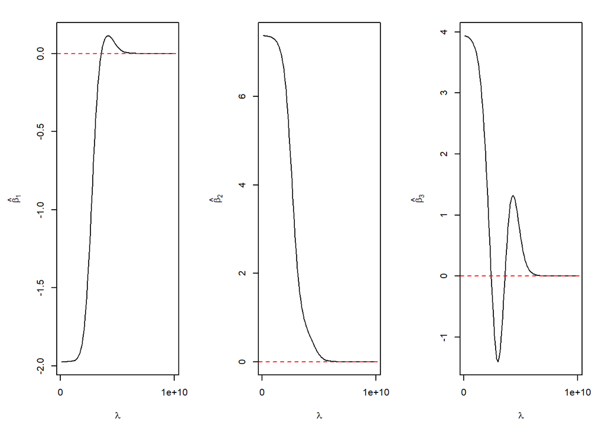

```r
#plot(ridge_grid$lambda)

# we need to sort them according to increasing values of lambda.
K = length(grid)
#coef_grid[2,K:1] #we resort the columns for beta 1 (row 2)

# e.g. for beta_1, beta_2, beta_3
par(mfrow = c(1,3), mar = c(5,5,2,2))

plot(coef_grid[2,K:1], type = "l", xlab = expression(lambda), ylab = expression(hat(beta)[1]), xaxt = "none")
abline(h = 0, col = "red", lty = "dashed")
axis(side = 1, at = c(0,100), labels = c(0,max(grid)))

plot(coef_grid[3,K:1], type = "l", xlab = expression(lambda), ylab = expression(hat(beta)[2]), xaxt = "none")
abline(h = 0, col = "red", lty = "dashed")
axis(side = 1, at = c(0,100), labels = c(0,max(grid)))

plot(coef_grid[4,K:1], type = "l", xlab = expression(lambda), ylab = expression(hat(beta)[3]), xaxt = "none")
abline(h = 0, col = "red", lty = "dashed")
axis(side = 1, at = c(0,100), labels = c(0,max(grid)))
```

We can see that as lambda increases, the coefficients shrink towards zero. However, ridge regression does not set any coefficients exactly to zero, so all predictors remain in the model.

How to choose lambda? We can use validation set approach or k-fold cross validation. This can be implemented with the function `cv.glmnet()` (by default k = 10), otherwise we can choose a different number by setting the parameter `nfolds`. The function performs *cross validation* for each value of lambda in the grid and returns the corresponding cross-validation error.

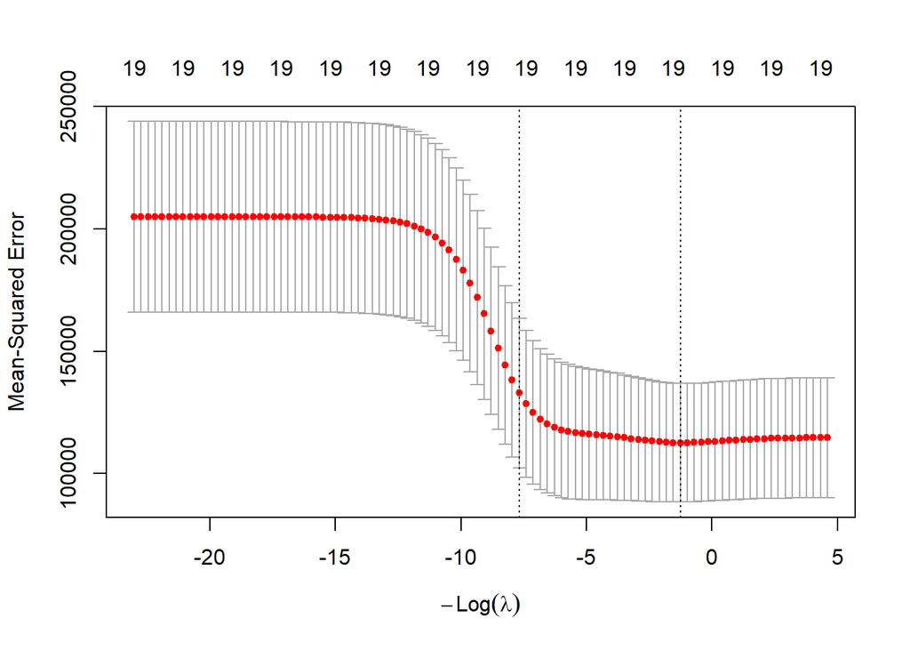

```r
cv.out = cv.glmnet(X, y, lambda = grid, alpha = 0)

# The function returns a collection of cv errors (one for each value of lambda)
par(mfrow = c(1,1))
plot(cv.out)
```

```r
# Optimal value of lambda (without log):
bestlam = cv.out$lambda.min

# which results in the vale -log(lamba)
bestlam_log = -log(bestlam) #point on the plot

bestlam;bestlam_log
```

```
[1] 3.511192
```

```
[1] -1.255956
```

The minimum CV error is achieved for lambda = 3.5111917, yet on the graph we see another lambda highlighted ($\lambda_1se$) this is, the largest value of lambda (penaly) which results into a simpler model which isn’t significantly worse than the one with lambda = bestlam. This is a more conservative choice since it favors simpler models, thus we could also choose lambda = 2154.43469 without sacrificing much predictive performance.

Finally, we fit the model for lambda = 3.5111917 on the complete dataset

```r
ridge_best = glmnet(X, y, alpha = 0, lambda = bestlam, standardize = TRUE)

ridge_best$a0
```

```
      s0
151.0088
```

```r
ridge_best$beta
```

```
19 x 1 sparse Matrix of class "dgCMatrix"
                      s0
AtBat        -1.66544563
Hits          5.87780603
HmRun         1.10131650
Runs         -0.53841674
RBI          -0.07576438
Walks         5.33761120
Years        -9.67599817
CAtBat       -0.06618126
CHits         0.18709851
CHmRun        0.59394040
CRuns         0.76958517
CRBI          0.42639714
CWalks       -0.62500222
LeagueN      61.38421638
DivisionW  -122.23368167
PutOuts       0.27965006
Assists       0.29835805
Errors       -3.71730684
NewLeagueN  -27.56095983
```

### Lasso method

We can implement Lasso simply by setting `alpha = 1` in `glmnet()` function. Again, we consider a grid of values for lambda and analyze the behavior of the coefficients as a function of lambda.

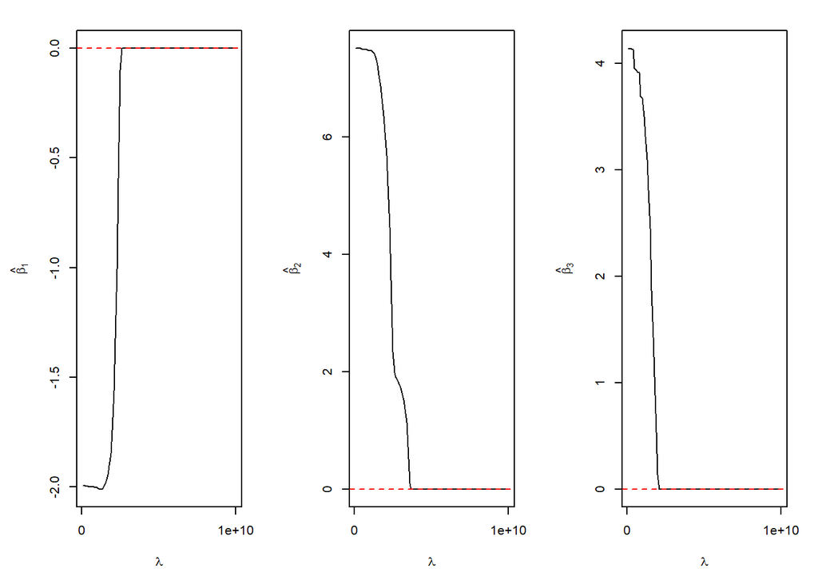

```r
lasso_grid = glmnet(X, y, alpha = 1, lambda = grid, standardize = TRUE)

beta_lasso = coef(lasso_grid)

par(mfrow = c(1,3), mar = c(5,5,2,2))

plot(coef(lasso_grid)[2,K:1], type = "l", xlab = expression(lambda), ylab = expression(hat(beta)[1]), xaxt = "none")
abline(h = 0, col = "red", lty = "dashed")
axis(side = 1, at = c(0,100), labels = c(0,max(grid)))

plot(coef(lasso_grid)[3,K:1], type = "l", xlab = expression(lambda), ylab = expression(hat(beta)[2]), xaxt = "none")
abline(h = 0, col = "red", lty = "dashed")
axis(side = 1, at = c(0,100), labels = c(0,max(grid)))

plot(coef(lasso_grid)[4,K:1], type = "l", xlab = expression(lambda), ylab = expression(hat(beta)[3]), xaxt = "none")
abline(h = 0, col = "red", lty = "dashed")
axis(side = 1, at = c(0,100), labels = c(0,max(grid)))
```

Differently from ridge coefficients, from some value of lambda on, are set to 0. This is, lasso performs variable selection by shrinking some coefficients to exactly zero, thus effectively removing those predictors from the model. This can lead to simpler and more interpretable models, especially when we have a large number of predictors.

Similarly as before, we can implement cross validation methods to choose lambda:

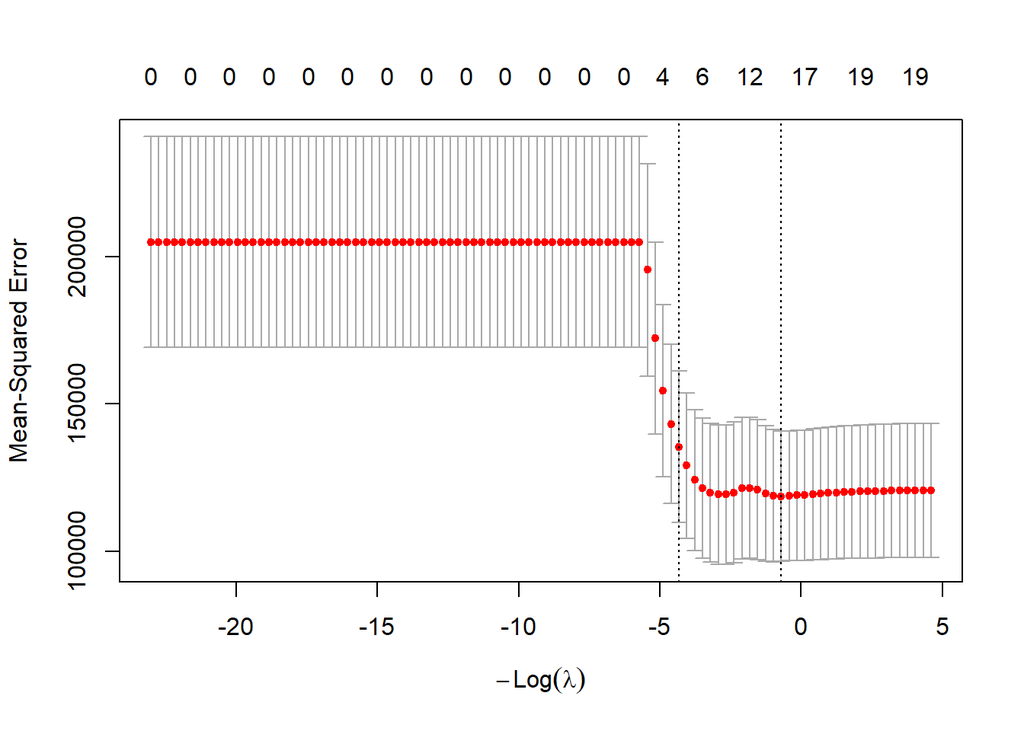

```r
cv.out = cv.glmnet(X, y, lambda = grid, alpha = 1)

par(mfrow = c(1,1))
plot(cv.out)
```

```r
# Optimal value of lambda (without log):
bestlam = cv.out$lambda.min

# which results in the vale -log(lamba)
bestlam_log = -log(bestlam) #point on the plot

bestlam;bestlam_log
```

```
[1] 2.009233
```

```
[1] -0.6977531
```

Finally, we fit our model for lambda = 2.009233 on the complete dataset

```r
lasso_best = glmnet(X, y, alpha = 1, lambda = bestlam, standardize = TRUE)

lasso_best$a0
```

```
      s0
138.5774
```

```r
lasso_best$beta
```

```
19 x 1 sparse Matrix of class "dgCMatrix"
                      s0
AtBat      -1.738992e+00
Hits        6.069735e+00
HmRun       1.916481e-01
Runs        .
RBI         .
Walks       5.062086e+00
Years      -1.012892e+01
CAtBat     -4.848784e-03
CHits       .
CHmRun      5.372552e-01
CRuns       7.418578e-01
CRBI        4.035978e-01
CWalks     -6.071203e-01
LeagueN     3.366555e+01
DivisionW  -1.190722e+02
PutOuts     2.773579e-01
Assists     2.131322e-01
Errors     -2.360102e+00
NewLeagueN  .
```

Ridge and Lasso are not competing methods — they encode different prior beliefs about the world. Ridge assumes signal is spread across many variables; Lasso assumes signal is concentrated in few. Multicollinearity specifically favors Ridge because it respects the shared information structure rather than making arbitrary selection choices.

## Riboflavin case

Bacterium named “Bacillus Subtilis” is used in agriculture for plant-growth. Its production of riboflavin (vitamin B2) is the main responsible of plant-growth. One objective is therefore to control/increase riboflavin production, e.g. by means of gene manipulation.

The problem on this dataset is to identify which genes (out of the 4088 available) are responsible of riboflavin production/regulation.

```r
data(riboflavin)
str(riboflavin)
```

```
'data.frame':   71 obs. of  2 variables:
 $ y: num  -6.64 -6.95 -7.93 -8.29 -7.31 ...
 $ x: 'AsIs' num [1:71, 1:4088] 8.49 7.64 8.09 7.89 6.81 ...
  ..- attr(*, "dimnames")=List of 2
  .. ..$ : chr [1:71] "b_Fbat107PT24.CEL" "b_Fbat107PT30.CEL" "b_Fbat107PT48.CEL" "b_Fbat107PT52.CEL" ...
  .. ..$ : chr [1:4088] "AADK_at" "AAPA_at" "ABFA_at" "ABH_at" ...
```

```r
y = riboflavin$y
X = riboflavin$x

length(y)
```

```
[1] 71
```

```r
dim(X)
```

```
[1]   71 4088
```

```r
str(X)
```

```
 'AsIs' num [1:71, 1:4088] 8.49 7.64 8.09 7.89 6.81 ...
 - attr(*, "dimnames")=List of 2
  ..$ : chr [1:71] "b_Fbat107PT24.CEL" "b_Fbat107PT30.CEL" "b_Fbat107PT48.CEL" "b_Fbat107PT52.CEL" ...
  ..$ : chr [1:4088] "AADK_at" "AAPA_at" "ABFA_at" "ABH_at" ...
```

```r
p = ncol(X)
n = nrow(X)
```

A linear model on this context fails because the number of observations is less than the number of predictors and thus traditional OLS fails. We know stepwise subset selection methods are computational expensive and tight by the model family we work, thus we would not be able to compute them on this setting. Therefore, we apply Lasso (as we want to select important variables).

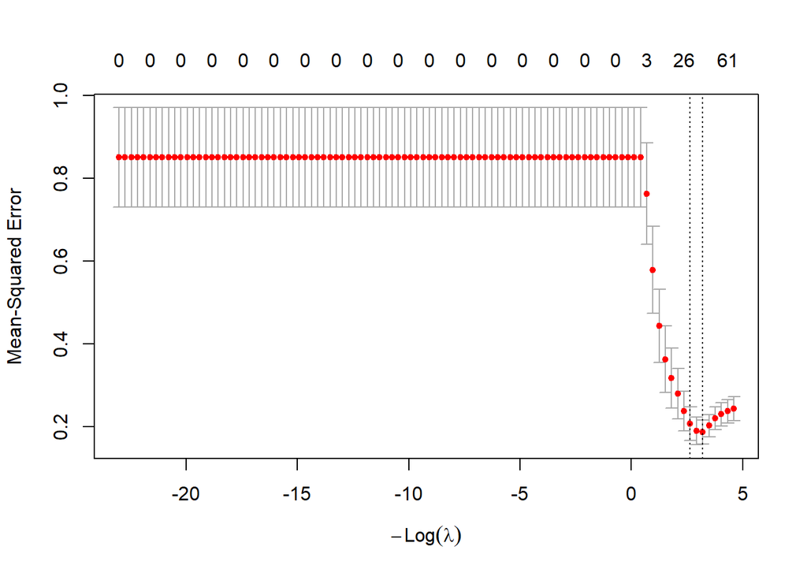

```r
lasso_grid = glmnet(X, y, alpha = 1, lambda = grid, standardize = TRUE)
beta_lasso = coef(lasso_grid)

# implement cross validation methods to choose the best lambda
cv.out = cv.glmnet(X, y, lambda = grid, alpha = 1)

# CV errors (one for each value of lambda)
par(mfrow = c(1,1))
plot(cv.out)
```

```r
# Optimal value of lambda is
bestlam = cv.out$lambda.min
bestlam
```

```
[1] 0.04037017
```

```r
# Finally, fit the model for lambda = bestlam on the complete dataset
lasso_best = glmnet(X, y, alpha = 1, lambda = bestlam, standardize = TRUE)

#lasso_best$a0
#lasso_best$beta
```

With the model applied we can select the genes on the model with non-zero coefficients and retrieve their names:

```r
genes_in = colnames(X)[which(lasso_best$beta != 0)]
coeff_in = lasso_best$beta[which(lasso_best$beta != 0)]

names(coeff_in) = genes_in
sort(round(coeff_in, 2), decreasing = TRUE)
```

```
 SPOVAA_at    YQJU_at    YCLB_at    XHLB_at    YBFI_at  YFHE_r_at  YHDS_r_at
      0.27       0.22       0.20       0.17       0.13       0.13       0.13
   YFIO_at    YKBA_at    PRIA_at    YFIR_at    PKSA_at    YURQ_at    GAPB_at
      0.11       0.11       0.07       0.07       0.05       0.05       0.04
   YLXW_at    YEZB_at    YUID_at    YCKE_at    YFII_at    YQJT_at SPOIIAA_at
      0.04       0.02       0.02       0.01       0.01       0.01       0.00
   YCGO_at    YDDH_at    YCDH_at    YACN_at    YRVJ_at    YTGB_at    YCLF_at
      0.00       0.00      -0.01      -0.02      -0.04      -0.04      -0.06
   YYBG_at    YYDA_at    YXLE_at    YDDK_at    DNAJ_at    ARGF_at    YXLD_at
     -0.06      -0.09      -0.12      -0.13      -0.14      -0.19      -0.19
   LYSC_at    YEBC_at    YOAB_at
     -0.28      -0.52      -0.79
```

# Trees

A tree-based method is a non-parametric supervised learning method. This means we don’t make assumptions about the functional form of the relationship between the response variable and the predictors. Instead we apply a sequence of decissions rules based on the observed data to predict/classify the response variable.

This is qeuivalent to stratify the predictor space to fund homogeneous response regions. The resulting model is a tree with branches corresponding to the predictor variables and leaves corresponding to the predicted response values.

Trees are very flexible and easy to interpret, they manage NAs and outlier natively, they can capture non-linear relationships and interactions between predictors. However, they can be unstable and have high variance. Trees are often used in ensemble methods (e.g. random forests, boosting) to improve their performance.

## Regression trees

We use the *wine* data set to analyse the quality of wine in relation to alcohol level, pH, etc.

```r
wine = read.csv(paste0(datawd,"/wine_quality.csv"), sep = ";")
wine |> skim()
```

Data summary

| Name | wine |
| --- | --- |
| Number of rows | 1599 |
| Number of columns | 12 |
| _______________________ |  |
| Column type frequency: |  |
| character | 1 |
| numeric | 11 |
| ________________________ |  |
| Group variables | None |

**Variable type: character**

| skim_variable | n_missing | complete_rate | min | max | empty | n_unique | whitespace |
| --- | --- | --- | --- | --- | --- | --- | --- |
| alcohol | 0 | 1 | 1 | 19 | 0 | 65 | 0 |

**Variable type: numeric**

| skim_variable | n_missing | complete_rate | mean | sd | p0 | p25 | p50 | p75 | p100 | hist |
| --- | --- | --- | --- | --- | --- | --- | --- | --- | --- | --- |
| fixed.acidity | 0 | 1 | 8.32 | 1.74 | 4.60 | 7.10 | 7.90 | 9.20 | 15.90 | ▂▇▂▁▁ |
| volatile.acidity | 0 | 1 | 0.53 | 0.18 | 0.12 | 0.39 | 0.52 | 0.64 | 1.58 | ▅▇▂▁▁ |
| citric.acid | 0 | 1 | 0.27 | 0.19 | 0.00 | 0.09 | 0.26 | 0.42 | 1.00 | ▇▆▅▁▁ |
| residual.sugar | 0 | 1 | 2.54 | 1.41 | 0.90 | 1.90 | 2.20 | 2.60 | 15.50 | ▇▁▁▁▁ |
| chlorides | 0 | 1 | 0.09 | 0.05 | 0.01 | 0.07 | 0.08 | 0.09 | 0.61 | ▇▁▁▁▁ |
| free.sulfur.dioxide | 0 | 1 | 15.87 | 10.46 | 1.00 | 7.00 | 14.00 | 21.00 | 72.00 | ▇▅▁▁▁ |
| total.sulfur.dioxide | 0 | 1 | 46.47 | 32.90 | 6.00 | 22.00 | 38.00 | 62.00 | 289.00 | ▇▂▁▁▁ |
| density | 0 | 1 | 2.21 | 9.66 | 0.99 | 1.00 | 1.00 | 1.00 | 100.37 | ▇▁▁▁▁ |
| pH | 0 | 1 | 3.31 | 0.15 | 2.74 | 3.21 | 3.31 | 3.40 | 4.01 | ▁▅▇▂▁ |
| sulphates | 0 | 1 | 0.66 | 0.17 | 0.33 | 0.55 | 0.62 | 0.73 | 2.00 | ▇▅▁▁▁ |
| quality | 0 | 1 | 5.64 | 0.81 | 3.00 | 5.00 | 6.00 | 6.00 | 8.00 | ▁▇▇▂▁ |

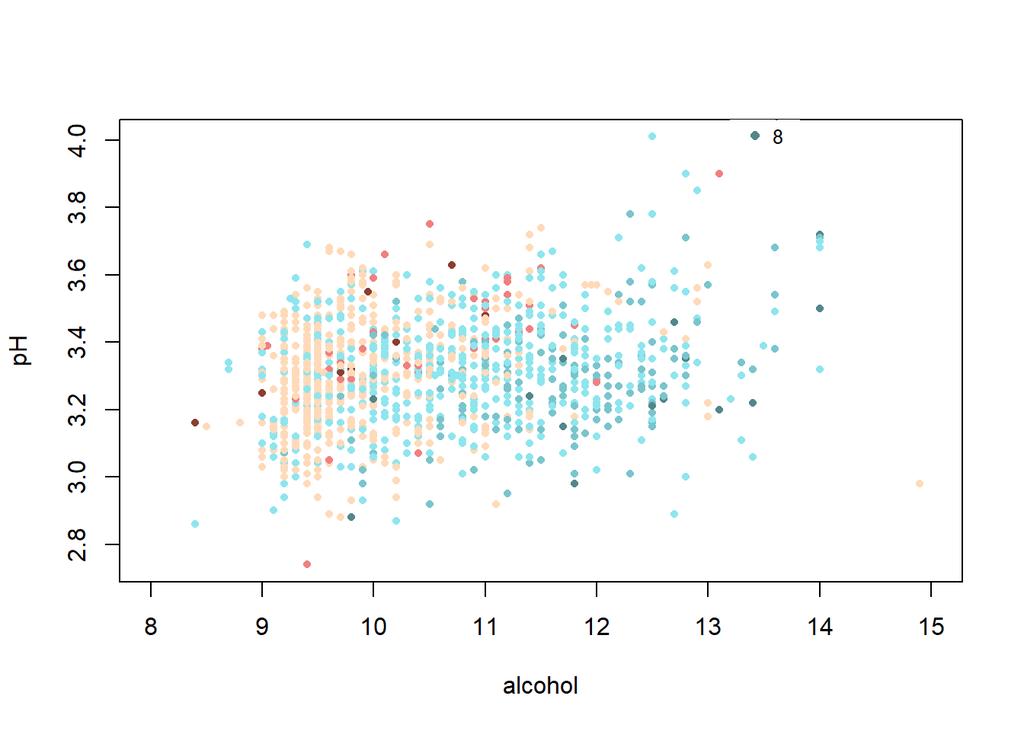

```r
# transform alcohol into num.
wine$alcohol = as.numeric(wine$alcohol)

attach(wine)

# observations
n = nrow(wine)

# quality color palette
col_quality = quality
col_quality[quality == 3] = "coral4"
col_quality[quality == 4] = "lightcoral"
col_quality[quality == 5] = "peachpuff1"
col_quality[quality == 6] = "cadetblue2"
col_quality[quality == 7] = "cadetblue3"
col_quality[quality == 8] = "cadetblue4"

#plot alcohol vs pH colored by quality
plot(alcohol, pH, xlim = c(8,15), col = col_quality, pch = 16, cex = 0.7)

legend(13.2, 4.5, legend = c("3", "4", "5", "6", "7", "8"),
       col = c("coral4", "coral2", "wheat2", "cadetblue2", "cadetblue3", "cadetblue4"),
       pch = 16, cex = 0.8, title = "Quality", box.col = "white")
```

We can se that most wines with low quality (points on red-yellow colors) tend to have low alcohol level but are more spread in terms of pH. On the other hand, most wines with high quality (blue tones) tend to have high alcohol levels.

We can use function `tree()` to fit the model into the data using recursive binary splitting. Syntax is very similar to function `lm()`. We start by including all the observations (without creating train and test sets).

```r
set.seed(123)
tree.wine = tree(quality ~ ., #to include all predictors in dataset
                 data = wine)

out.wine = summary(tree.wine)
out.wine
```

```
Regression tree:
tree(formula = quality ~ ., data = wine)
Variables actually used in tree construction:
[1] "alcohol"          "sulphates"        "volatile.acidity"
Number of terminal nodes:  8
Residual mean deviance:  0.428 = 678.4 / 1585
Distribution of residuals:
   Min. 1st Qu.  Median    Mean 3rd Qu.    Max.
-2.4000 -0.4000 -0.1220  0.0000  0.4247  2.1670
```

```r
out.wine$used
```

```
[1] alcohol          sulphates        volatile.acidity
12 Levels: <leaf> fixed.acidity volatile.acidity citric.acid ... alcohol
```

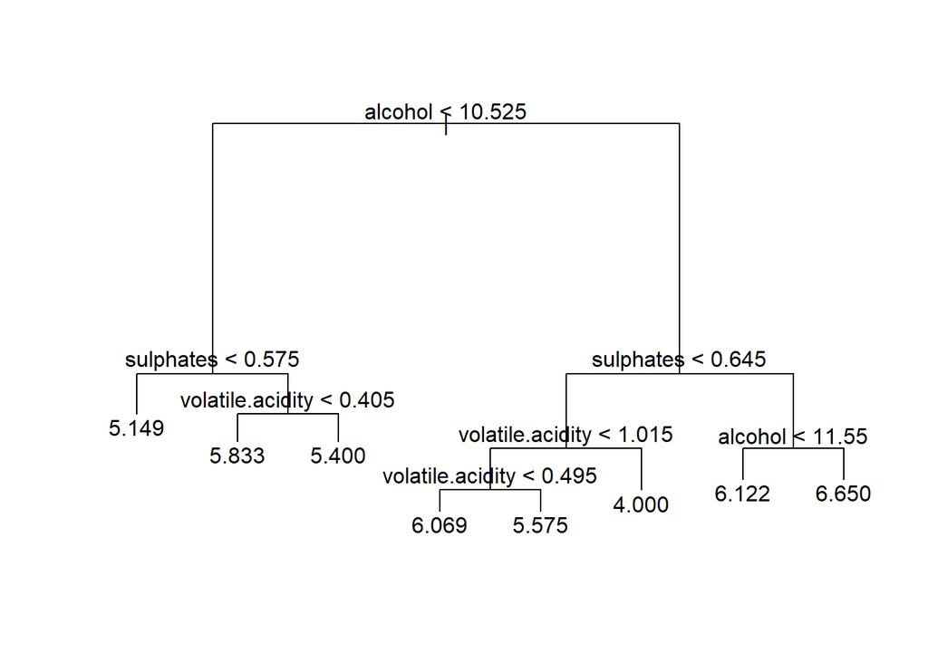

```r
plot(tree.wine)
text(tree.wine) # to add labels
```

We can also check properties of the observations on each leaf (region).

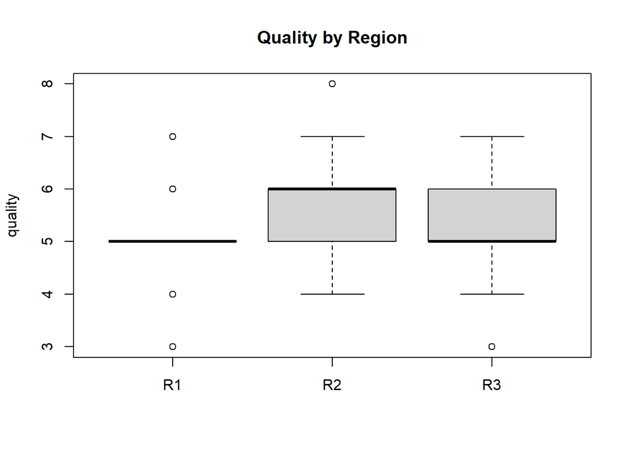

```r
# REGION 1 (corresponding to alcohol < 10.525 and sulphates < 0.575)
R1 = quality[alcohol < 10.525 & sulphates < 0.575]

# REGION 2
R2 = quality[alcohol < 10.525 & sulphates >= 0.575 & volatile.acidity < 0.405]

# REGION 3
R3 = quality[alcohol < 10.525 & sulphates >= 0.575 & volatile.acidity >= 0.405]

# distribution of quality within R1
boxplot(R1, R2, R3, names = c("R1", "R2", "R3"),
        main = "Quality by Region", ylab = "quality")
```

```r
# predicted value for each region (mean of quality in each region)
c(mean(R1, na.rm = TRUE),
  mean(R2, na.rm = TRUE),
  mean(R3, na.rm = TRUE) )
```

```
[1] 5.148718 5.833333 5.400000
```

On the boxplot R1 seems to show no box. This is because observations on R1 have a tight distribution around 5, thus the boxplot is not able to capture the variability of the data. The predicted value for R1 is 5.149, for R2 is 5.833 and for R3 is 5.400 as shown in the previous tree plot.

### Training cost and complexity prunning

Now we consider a test and train split. To avoid the problem of instability of spliting we set a seed (uniform across chunks).

```r
set.seed(123)
train = sample(1:n, n/2)

tree.wine = tree(quality ~ ., wine, subset = train)
summary(tree.wine)
```

```
Regression tree:
tree(formula = quality ~ ., data = wine, subset = train)
Variables actually used in tree construction:
[1] "alcohol"              "sulphates"            "volatile.acidity"
[4] "total.sulfur.dioxide" "residual.sugar"       "fixed.acidity"
Number of terminal nodes:  12
Residual mean deviance:  0.4027 = 315.3 / 783
Distribution of residuals:
    Min.  1st Qu.   Median     Mean  3rd Qu.     Max.
-2.32200 -0.32240 -0.09375  0.00000  0.25560  2.25600
```

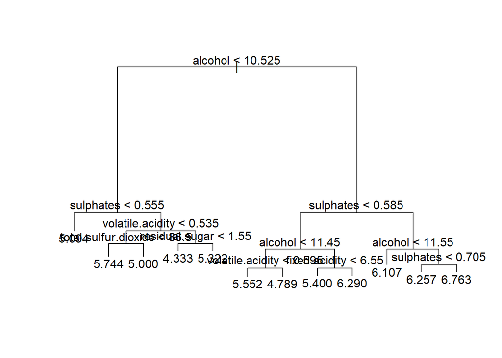

```r
# Estimated tree on the training data is
plot(tree.wine)
text(tree.wine)
```

Now we prune our tree using cost complexity pruning. Output is a collection of sub-trees corresponding to different sizes (and values of alpha). To choose the best sub-tree we use cross validation (by default K-fold cross validation is implemented). All these steps are implemented in the function `cv.tree()` which takes as input an object of type tree k-fold cross validation is implemented on the dataset used to fit the tree only.

```r
cv.wine = cv.tree(tree.wine, K = 10) # K = 10 for 10-fold cross validation

# sizes of the estimated sub-trees (obs: in decreasing order)
cv.wine$size
```

```
 [1] 12 11 10  9  8  6  5  4  3  2  1
```

```r
# corresponding RSS (CV errors)
cv.wine$dev
```

```
 [1] 396.2933 394.8312 394.8312 397.8812 392.1870 408.8949 416.2856 423.1203
 [9] 421.8382 439.9656 544.8887
```

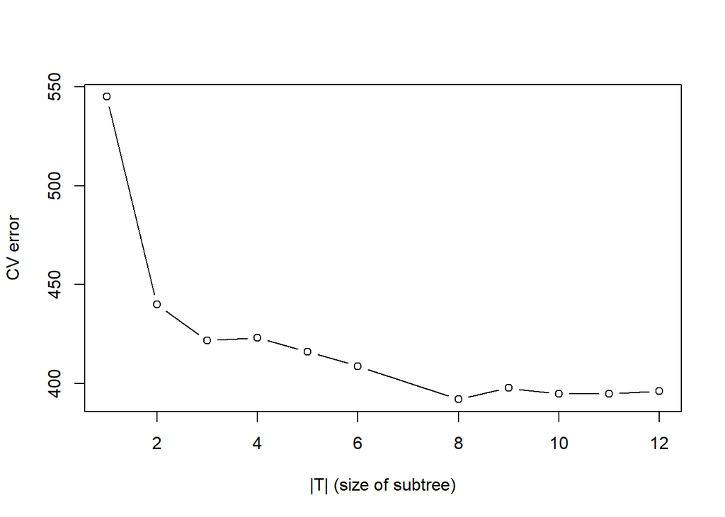

```r
# plot the CV errors to find the optimal sub-tree
plot(cv.wine$size, cv.wine$dev, type = "b", xlab = "|T| (size of subtree)", ylab = "CV error")
```

```r
# Save minimum CV error and the corresponding size
min.rss = which.min(cv.wine$dev)
size.best = cv.wine$size[min.rss]
```

Trees are quite sensitive to the choice of the training set. Therefore, we can repeat this procedure a number of times and each time we obtain a best size.

To obtain the pruned tree we can use the function `prune.tree()` this functions requieres as input an object of type tree (output of `tree()`) and the size of the best sub-tree obtained with `cv.tree()`.

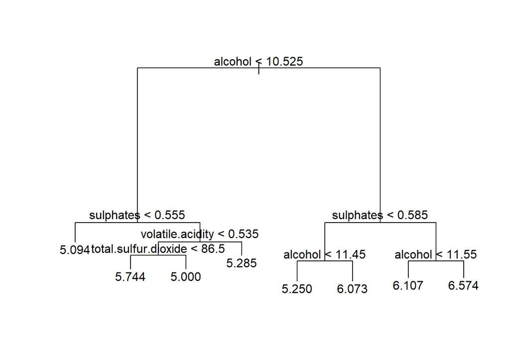

```r
#pruned tree
prune.wine = prune.tree(tree.wine, best = size.best)

plot(prune.wine)
text(prune.wine)
```

### Testing the model

Now, we evaluate the fitting on the test data set, this is we will predict the wine quality for the observation in the test set and compare them with the observed values.

```r
# test set
test = setdiff(1:n, train)

# quality predictions
quality.hat = predict(prune.wine, newdata = wine[test,])
unique(quality.hat)
```

```
[1] 5.284810 5.744361 5.093750 5.000000 5.250000 6.073171 6.574468 6.107143
[9] 5.651572
```

As we can see predicted values are uniform within each region. Our pruned tree has 8 terminal nodes and we have recovered a vector of predicted values with 9 unique values.

These vector includes the predicted values and potentially edge cases or rounding where prediction fall at different precision levels when appyling the model to the test set.

This difference between predicted values and prediction values can happen when: 1. Different leaves have been assigned the same predicted value. 2. Some leaves aren’t reached by any test observations (though `unique()` would show fewer values in that case)

```r
# select test data for variable quality (y.test)
quality.test = wine[-train, "quality"]

# Residual Sum of Squares (RSS) is then
mean((quality.test - quality.hat)^2)
```

```
[1] 0.454317
```

## Classification trees

We consider the previously seen titanic dataset to study the survival probability this time by using classification trees instead of logistic regression. Notice that Survived (the response variable y, 0 if no, 1 if yes) is an integer vector, therefore it will be treated as a quantitative variable. To fit a classification tree, I need to convert it into a factor.

Train and test sets are divided into 50-50% of the data. We also appy `model.matrix()` in order to convert factor variables (Sex) into dummies.

```r
titanic = read.csv(paste0(datawd,"/titanic_train.csv"))

#remove NA's
titanic = titanic[complete.cases(titanic),]
titanic |> skim()
```

Data summary

| Name | titanic |
| --- | --- |
| Number of rows | 714 |
| Number of columns | 12 |
| _______________________ |  |
| Column type frequency: |  |
| character | 5 |
| numeric | 7 |
| ________________________ |  |
| Group variables | None |

**Variable type: character**

| skim_variable | n_missing | complete_rate | min | max | empty | n_unique | whitespace |
| --- | --- | --- | --- | --- | --- | --- | --- |
| Name | 0 | 1 | 13 | 82 | 0 | 714 | 0 |
| Sex | 0 | 1 | 4 | 6 | 0 | 2 | 0 |
| Ticket | 0 | 1 | 3 | 18 | 0 | 542 | 0 |
| Cabin | 0 | 1 | 0 | 15 | 529 | 135 | 0 |
| Embarked | 0 | 1 | 0 | 1 | 2 | 4 | 0 |

**Variable type: numeric**

| skim_variable | n_missing | complete_rate | mean | sd | p0 | p25 | p50 | p75 | p100 | hist |
| --- | --- | --- | --- | --- | --- | --- | --- | --- | --- | --- |
| PassengerId | 0 | 1 | 448.58 | 259.12 | 1.00 | 222.25 | 445.00 | 677.75 | 891.00 | ▇▇▇▇▇ |
| Survived | 0 | 1 | 0.41 | 0.49 | 0.00 | 0.00 | 0.00 | 1.00 | 1.00 | ▇▁▁▁▆ |
| Pclass | 0 | 1 | 2.24 | 0.84 | 1.00 | 1.00 | 2.00 | 3.00 | 3.00 | ▅▁▃▁▇ |
| Age | 0 | 1 | 29.70 | 14.53 | 0.42 | 20.12 | 28.00 | 38.00 | 80.00 | ▂▇▅▂▁ |
| SibSp | 0 | 1 | 0.51 | 0.93 | 0.00 | 0.00 | 0.00 | 1.00 | 5.00 | ▇▁▁▁▁ |
| Parch | 0 | 1 | 0.43 | 0.85 | 0.00 | 0.00 | 0.00 | 1.00 | 6.00 | ▇▁▁▁▁ |
| Fare | 0 | 1 | 34.69 | 52.92 | 0.00 | 8.05 | 15.74 | 33.38 | 512.33 | ▇▁▁▁▁ |

```r
# integer to factor
titanic$Survived = as.factor(titanic$Survived)

attach(titanic)

# spliting
n = nrow(titanic)

set.seed(123)
train = sample(1:n, n/2)
test  = setdiff(1:n, train)

# Select the response y
y = as.factor(titanic$Survived)

# Select the covariates
X.tmp = as.data.frame(titanic[,c(3,5:8,10)])

# transform factor variables into dummies
X = model.matrix(y ~ ., X.tmp)[,-1]
X = as.data.frame(X)

head(X)
```

```
  Pclass Sexmale Age SibSp Parch    Fare
1      3       1  22     1     0  7.2500
2      1       0  38     1     0 71.2833
3      3       0  26     0     0  7.9250
4      1       0  35     1     0 53.1000
5      3       1  35     0     0  8.0500
7      1       1  54     0     0 51.8625
```

```r
attach(X)

# vectors from train and test sets
y_train = y[train]
y_test  = y[test]

X_train = X[train,]
X_test  = X[test,]
```

### Training the model

Fit a classification tree (using recursive binary splitting) on the train dataset.

```r
tree.titanic = tree(y_train ~ ., data = X_train)
out = summary(tree.titanic)
out
```

```
Classification tree:
tree(formula = y_train ~ ., data = X_train)
Variables actually used in tree construction:
[1] "Sexmale" "Pclass"  "Fare"    "Age"     "SibSp"
Number of terminal nodes:  9
Residual mean deviance:  0.7387 = 257.1 / 348
Misclassification error rate: 0.1513 = 54 / 357
```

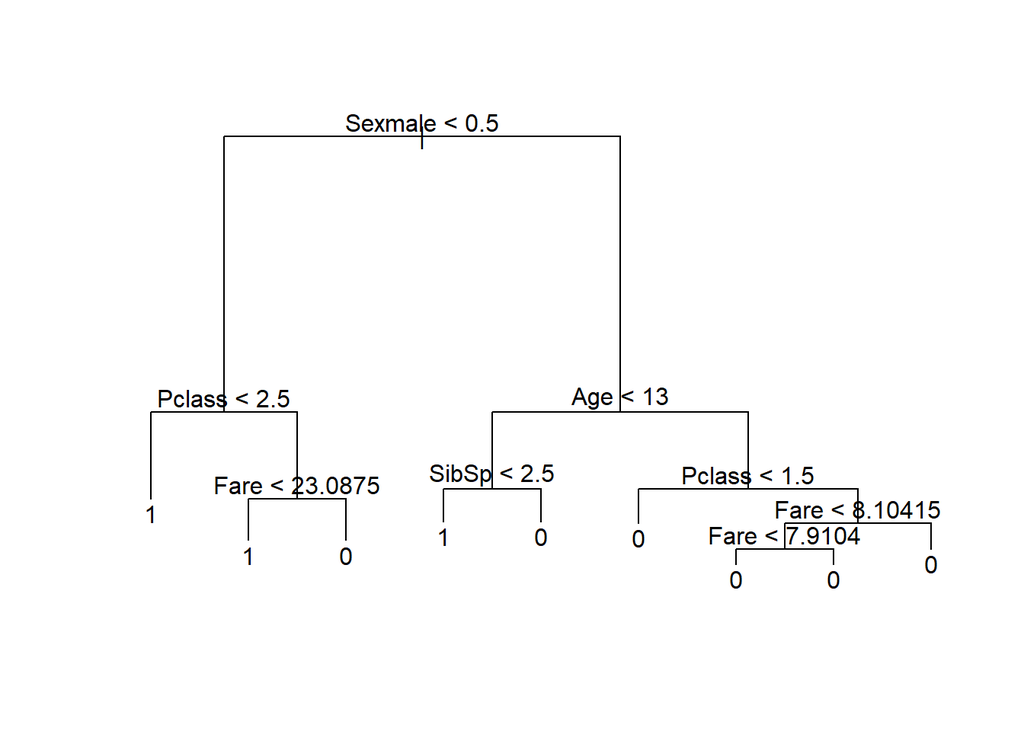

```r
plot(tree.titanic)
text(tree.titanic)
```

As we’ve shown, X matrix is composed by 6 predictor, but only 5 are used on the tree (‘Parch’ was discarded). For a clasiffication tree predicted values are the most common class in each region (leaf), this make it widely different from a logistic regression where predicted values are probabilities.

### Prunning

Now we can implement *cost complexity pruning* by cross validation:

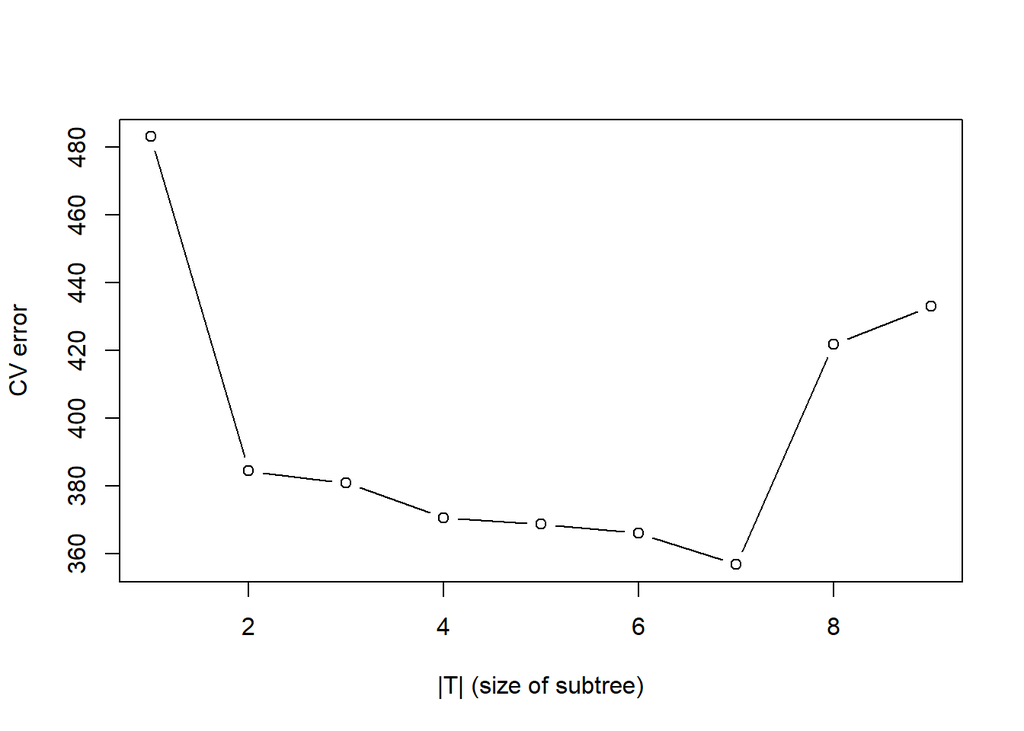

```r
set.seed(123)
cv.titanic = cv.tree(tree.titanic, K = 10)

plot(cv.titanic$size, cv.titanic$dev, type = "b", xlab = "|T| (size of subtree)", ylab = "CV error")
```

```r
# Save minimum CV error and the corresponding size
min.rss = which.min(cv.titanic$dev)
size.best = cv.titanic$size[min.rss]
```

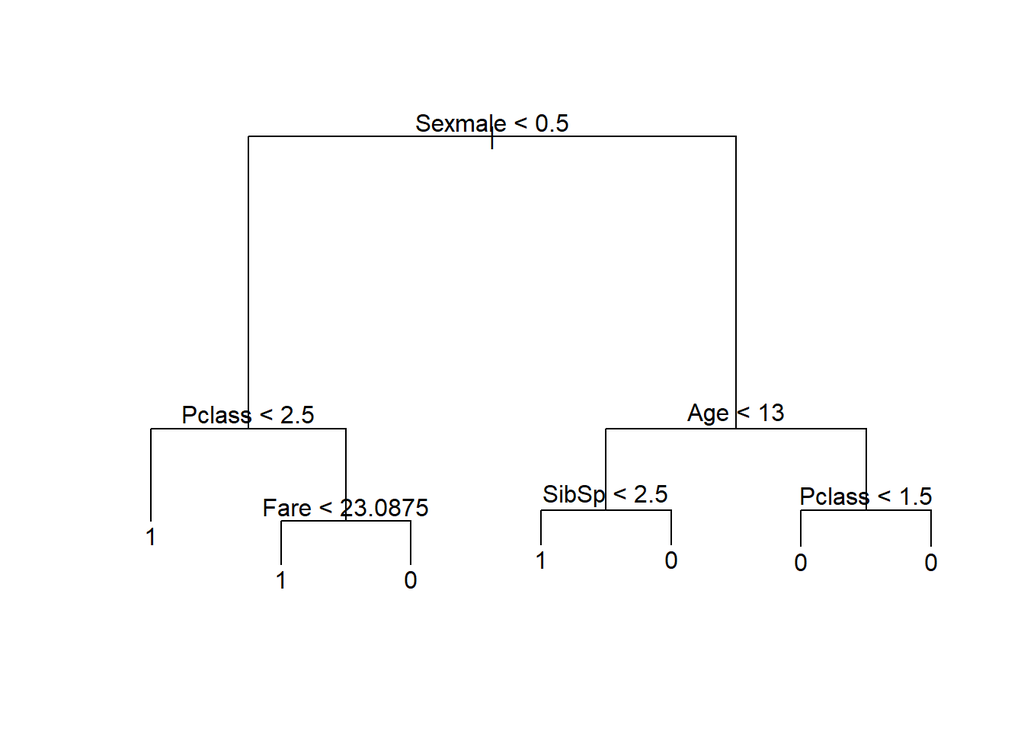

```r
prune.titanic = prune.tree(tree.titanic, best = size.best)

plot(prune.titanic)
text(prune.titanic)
```

### Testing the model

We predict Survived for passengers in the test set. The method predict won’t give 0 or 1 but a probability, that is, the frequency of observations with survival. In consequence, we need to set a threshold to convert probabilities into 0-1 prediction. In this case we set that threshold to 0.5.

```r
# make predictions for test set (probabilities)
pi.hat = predict(prune.titanic, newdata = X_test)
p.hat = pi.hat[,2]
p.hat |> head()
```

```
         1          2          3          4          7          8
0.09615385 0.93243243 0.64285714 0.93243243 0.32000000 0.16666667
```

```r
# re-encode predictions according to threshold
y.hat = ifelse(p.hat > 0.5, 1, 0)
```

To compare predicted and observed values of y (survival), we can construct a contingency table (confussion matrix).

```r
#contingency table
confusion = table(y_test, y.hat)
confusion
```

```
      y.hat
y_test   0   1
     0 183  27
     1  42 105
```

Considering this, the error rate is the sum of the off-diagonal elements (wrong predictions) divided by the total number of observations in the test set.

```r
# test error rate
er = (confusion[1,2] + confusion[2,1])/sum(confusion)
er
```

```
[1] 0.1932773
```

# Bootstrap

As we’ve seen conclussions obtaines from a statistical model are sample dependent, bootstrap is a resampling method that allows us to estimate the distribution of our estrimators amor different samples. This is particularly useful when we don’t have closed-form results for the sampling distribution of our estimator, or when we want to obtain confidence intervals for it.

## on OLS parameter distribution

We consider the linear model $Y = \alpha + \beta*x + \epsilon$ where $\epsilon \sim N(0,\sigma^2)$

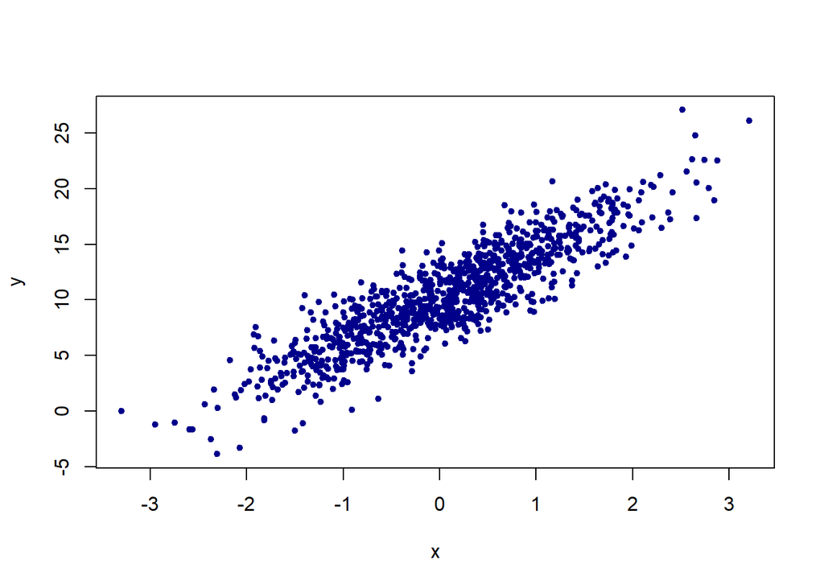

```r
# Generate n = 1000 obs for some values of parameters alpha, beta, sigma
n = 1000

beta0 = 10 #alpha
beta1 = 4 #beta
sigma = 2 #sd of error term

set.seed(300)

eps = rnorm(n, 0, sigma) #simulation of error term
x   = rnorm(n) #simulation of x
y   = beta0 + beta1*x + eps #simulation of y according to model

# Plot the n = 1000 data points
plot(x, y, ylab = "y", xlab = "x", col = "blue4", pch = 20)
```

We can compute the (true) mean and variance of the estimator of $\beta_1$ let’s remember that the OLS estimator of $\beta_1$ is given by: $\hat \beta_1 \sim N(\beta_1,[\sigma^2(X'X)^{-1}]_{2,2})$ where $X$ is the data matrix with a unit column for the intercept term and a column for x.

```r
X = cbind(1, x) #add the intercept term to the data matrix

mean_beta1 = beta1

var_beta1  = (sigma^2*solve((t(X)%*%X)))[2,2]

print(c(mean_beta1, var_beta1))
```

```
[1] 4.000000000 0.003897071
```

As we can see the variance of our estimator depends on the sample data (x). We can approximate the distribution of $\hat \beta_1$ using bootstrap method:

```r
# vector of observations to be selected from the original data (x,y)
set = sample(1:n, n, replace = TRUE)

# apply ols to the corresponding y and x values for the selected sample
out = lm(y[set] ~ x[set])

# we extract the estimated beta1 from the output of lm
out$coefficients[2]
```

```
  x[set]
4.045368
```

We repeat this procedure B times to obtain a collection of B bootstrap estimates of $\beta_1$

```r
# establish the number of bootstrap iterations (draws)
B = 5000

# create empty vector where we will store bootstrap estimates of beta1
out_boot = c()

for(b in 1:B){

  set = sample(1:n, n, replace = TRUE) # each timewe randomly draw a sample of size n from my population

  out_boot[b] = lm(y[set] ~ x[set])$coefficients[2] # I estimate (and store) beta1 using lm

}

head(out_boot)
```

```
[1] 4.065654 3.953330 3.985399 4.056537 4.043312 3.995642
```

Now we plot to visually inspect the distribution of the bootstrap estimates of $\beta_1$ and compare it with the true distribution of $\hat \beta_1$ (which is normal with mean beta1 and variance var_beta1).

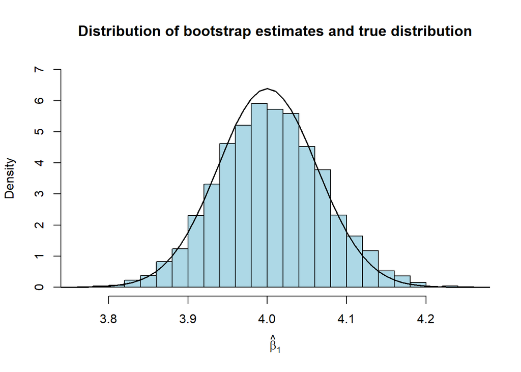

```r
# Distribution of beta_hat approximated by bootstrap is
hist(out_boot,
     xlab = expression(hat(beta)[1]),
     main = "Distribution of bootstrap estimates and true distribution",
     col = "lightblue", freq = FALSE, ylim = c(0, 7), breaks = 30)

# add the true distribution of beta_hat
plot(function(x) dnorm(x, mean_beta1, sd = sqrt(var_beta1)),
     from = 3.5, to = 4.5,
     add = TRUE, col = "black", lwd = 1.5)
```

## Example on asset allocation

On some cases we don’t have closed-form results for the sampling distribution estimator. We consider the Portfolio dataset which contains 100 returns for two assets X and Y.

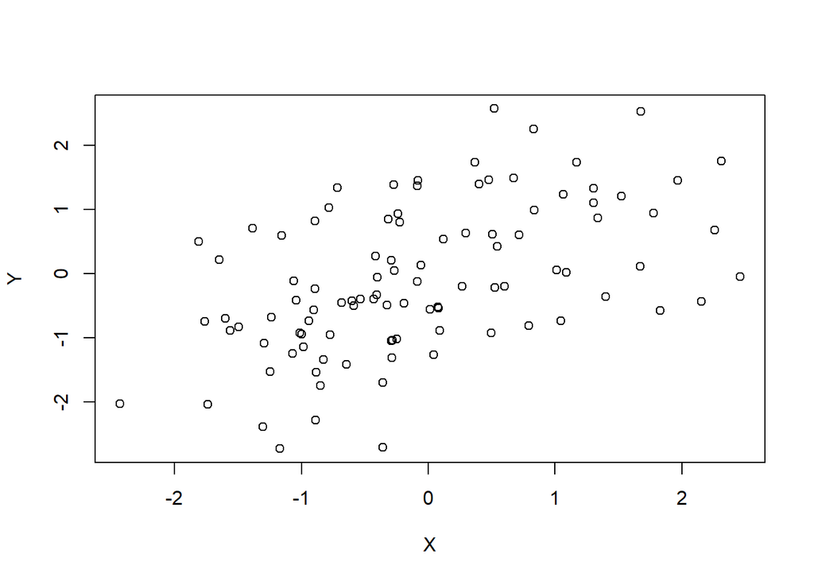

```r
plot(Portfolio)
```

We want to determine on wich proportions should we invest on each asset to minimize the risk of the portfolio, being $\alpha$ the propotion invested in asset X and $1-\alpha$ the propotion invested in asset Y.

The risk of the portfolio is measured by the variance of the return of the portfolio, that is, $Var(\alpha*X + (1-\alpha)*Y)$. We can estimate this variance for each propotion of assets (value of $\alpha$) and then select the value of $\alpha$ that minimizes it.

```r
# extract x and y from the dataset
x = Portfolio$X
y = Portfolio$Y

# The optimal value of alpha (sets derivative of portfolio variance to zero) is given by the following formula:
(var(y)-cov(x,y))/(var(x) + var(y) - 2*cov(x,y))
```

```
[1] 0.5758321
```

This optimum point is sample dependent, therefore we can use the bootstrap to estimate the distribution of $\alpha$ across samples and obtain confidence intervals for it.

We start by defining a function to estimate $\alpha$ (best allocation between the two assets) based on the optimization process of the variance of the portfolio. The function depends on “population” data and a vector (index) indexing the data that at each bootstrap iteration must be used to compute the estimate. In our example, data is a two-column dataframe with X and Y. If, for instance, we fix index = 1:100 all 100 observations are used to estimate alpha.

```r
# alpha function
alpha.fn = function(data, index){

  X = data$X[index]
  Y = data$Y[index]

  alpha_hat = (var(Y) - cov(X,Y))/(var(X) + var(Y) - 2*cov(X,Y))

  return(alpha_hat)
}

alpha.fn(Portfolio, 1:100)
```

```
[1] 0.5758321
```

Each bootstrap estimate can be instead obtained by randomly drawing with replacement 100 observations from the dataset, i.e. by setting `index = sample(1:100, 100, replace = T)`.

```r
alpha.fn(data = Portfolio, index = sample(100, 100, replace = T))
```

```
[1] 0.6355738
```

We need to reiterate the previous command for number of bootstrap iterations B = 5000. We can do this using a `for()` cycle (as in the first example) or the function `boot()` which requires three arguments: a dataset, a function to be applied on, the number of bootstrap iterations. The function result is an estimate of the standard error of the estimator defined by `alpha.fn()`.

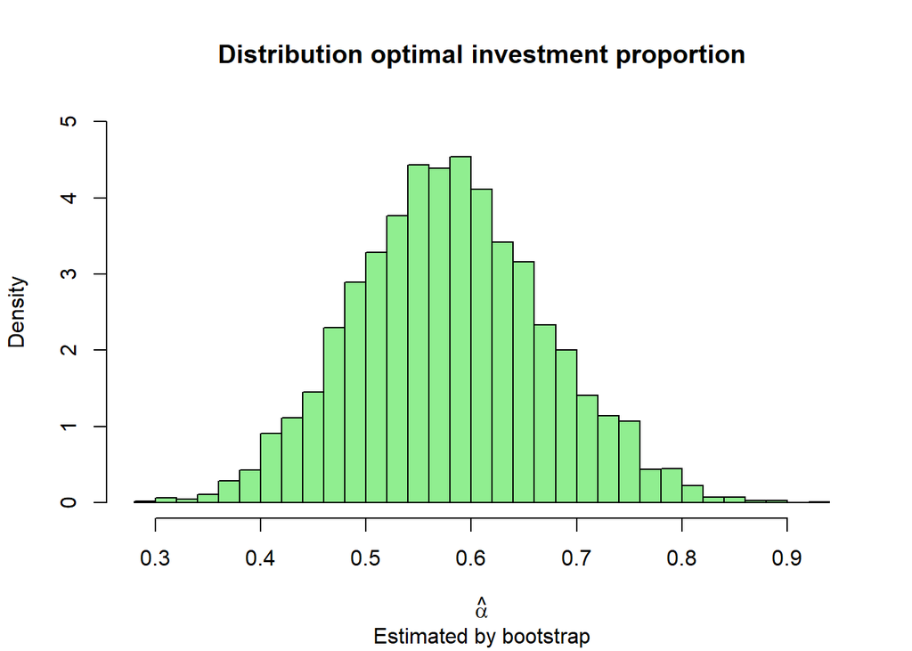

```r
out_boot = boot(Portfolio, alpha.fn, R = 5000)

# out_boot$t collects the R bootstrap draws
hist(out_boot$t,
     xlab = expression(hat(alpha)),
     main = "Distribution optimal investment proportion",
     sub = "Estimated by bootstrap",
     col = "lightgreen", freq = FALSE, ylim = c(0, 5), breaks = 30)
```

From the output we can recover, the expected value and standard deviation of the estimator, as well as confidence intervals:

```r
mean(out_boot$t)
```

```
[1] 0.5797734
```

```r
sd(out_boot$t)
```

```
[1] 0.09075802
```

```r
quantile(out_boot$t, c(0.025,0.975))
```

```
     2.5%     97.5%
0.4093305 0.7613166
```